# codingRMD_MNK

MNK

2024-08-06

# Packages

```r
if(!requireNamespace("rempsyc")) install.packages("rempsyc"); library(rempsyc)
if(!requireNamespace("flextable")) install.packages("flextable"); library(flextable)
if(!requireNamespace("broom")) install.packages("broom"); library(broom)
if(!requireNamespace("report")) install.packages("report"); library(report)
if(!requireNamespace("effectsize")) install.packages("effectsize"); library(effectsize)
if(!requireNamespace("tinytex")) install.packages("tinytex"); library(tinytex)
if(!requireNamespace("haven")) install.packages("haven"); library(haven)
if(!requireNamespace("dplyr")) install.packages("dplyr"); library(dplyr)
if(!requireNamespace("visdat")) install.packages("visdat"); library(visdat)
if(!requireNamespace("naniar")) install.packages("naniar"); library(naniar)
if(!requireNamespace("psych")) install.packages("psych"); library(psych)
if(!requireNamespace("mice")) install.packages("mice"); library(mice)
if(!requireNamespace("Hmisc")) install.packages("Hmisc"); library(Hmisc)
if(!requireNamespace("knitr")) install.packages("knitr"); library(knitr)
if(!requireNamespace("kableExtra")) install.packages("kableExtra"); library(kableExtra)
if(!requireNamespace("lavaan")) install.packages("lavaan"); library(lavaan)
if(!requireNamespace("semPlot")) install.packages("semPlot"); library(semPlot)
```

# Loading files (and predefined transformation)

## EMC data

```r
setwd("V:/Research/Dementie/Studenten/Studenten/Max/Databeheer")

dataEMC <- haven::read_sav("data_SCTQ_merged_16072024.sav") #load EMC collected data
dataEMC[dataEMC == 999] <- NA

dataEMC_copy <- dataEMC
```

## UMCG data

```r
setwd("V:/Research/Dementie/Studenten/Studenten/Max/Databeheer")
dataUMCG <- haven::read_sav("data_SC_UMCG_mnk.sav") #load UMCG collected data
dataUMCG[dataUMCG == 999] <- NA

dataUMCG_copy <- dataUMCG
```

# Data preprocessing

## Pre defined transformation

```r
dataEMC$TAS20_fac1_tf <- 35 - dataEMC$TAS20_fac1_Identificeren_Gevoelens
dataUMCG$TAS20_fac1_tf <- 35 - dataUMCG$TAS20_fac1_Identificeren_Gevoelens
```

## Synchronizing names and compute totals

```r
dataEMC$FP_1_6_total <- dataEMC$FP_1t6_ToM + dataEMC$FP_1t6_empathy
colnames(dataUMCG)[which(colnames(dataUMCG) == "SET_UMCG_Totaal")] <- "SET_UMCG_total"
dataEMC$SET_UMCG_Cognitief_Totaal <- dataEMC$SET_UMCG_1 +dataEMC$SET_UMCG_2 + dataEMC$SET_UMCG_3
dataEMC$SET_UMCG_Affectief_Totaal <- dataEMC$SET_UMCG_4 +dataEMC$SET_UMCG_5 + dataEMC$SET_UMCG_6
```

## Creating ID values for UMCG sample

```r
dataUMCG$ID <- paste0("UMCG", seq(1, nrow(dataUMCG)))
```

## Data pooling

```r
data_pooled <- dplyr::bind_rows(dataEMC, dataUMCG) # pooling the data
data_pooled_copy <- data_pooled
```

## Renaming and var name sets

```r
names_relevant_items <- c("Ekman60_total", "ERT_total", "TAS20_fac1_tf",
                          "FP_1_6_total", "hintingtask_total", "cartoons_total", "SET_total_mc", "SET_UMCG_total",
                          "SNQ_NL_total", "RSMS_AMSP", "MBI_total")
names_rel_items_abbr <- c('EKM60t', 'ERTt', 'TASf1',
                          'FP_Gt', 'HT_Gt', 'CART_Gt', 'SETt', 'SET_Gt',
                          'SNQt', 'RSMSf1', 'MBIt')
names(data_pooled)[match(names_relevant_items, names(data_pooled))] <- names_rel_items_abbr #renaming
names_covariates <- c("age", "sex", "education_level")
```

## Missing values part 1; visualisation

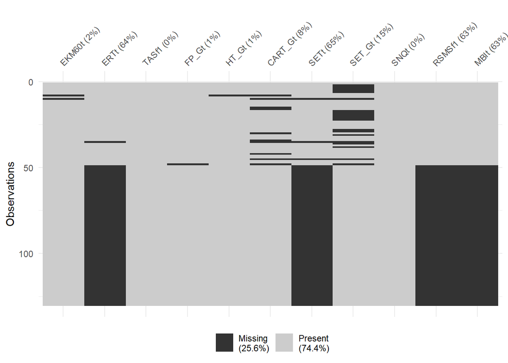

```r
vis_miss(data_pooled[,names_rel_items_abbr])
```

15% of data is missing for SET_Gt, all these missings are in the EMC data. For those people, SET was conducted with another testing protocol (solely multiple choise question, no open questions). We will impute SET_Gt scores for these people based on means in the EMC sample corrected for their scores on the MC questions.

Imputation will be continued after checks for outliers and non-normality.

# Data checks

## EMC sample data checks

Descriptes before outlier deletion and/or tranformations

```r
# Descriptives EMC start
psych::describe(data_pooled[data_pooled$centerID == "EMC", c(names_covariates, "MoCA_total", names_rel_items_abbr)]) %>%
  select(n, min, max, mean, median, sd, skew, kurtosis)
```

|  | n | min | max | mean | median | sd | skew | kurtosis |
| --- | --- | --- | --- | --- | --- | --- | --- | --- |
| age | 48 | 21.0 | 79 | 48.1458333 | 54.5 | 19.4826596 | -0.1268015 | -1.49580710 |
| sex | 48 | 0.0 | 1 | 0.6666667 | 1.0 | 0.4763931 | -0.6851252 | -1.56184896 |
| education_level | 48 | 2.0 | 7 | 5.6875000 | 6.0 | 1.1138633 | -1.0080362 | 1.12508564 |
| MoCA_total | 48 | 19.0 | 30 | 25.9375000 | 26.0 | 2.6207539 | -0.6903384 | 0.03587173 |
| EKM60t | 46 | 34.0 | 58 | 47.0000000 | 47.5 | 5.3748385 | -0.4905802 | 0.08902367 |
| ERTt | 47 | 34.0 | 76 | 56.7446809 | 57.0 | 9.7411456 | -0.1567050 | -0.67696312 |
| TASf1 | 48 | 5.0 | 28 | 20.0416667 | 21.0 | 5.4184803 | -0.5982728 | -0.04750892 |
| FP_Gt | 47 | 10.5 | 24 | 20.4042553 | 21.0 | 2.4773722 | -1.2891461 | 3.17165835 |
| HT_Gt | 47 | 6.0 | 12 | 11.2127660 | 12.0 | 1.1216481 | -2.3127911 | 7.57553160 |
| CART_Gt | 38 | 2.5 | 12 | 8.0000000 | 8.0 | 2.6278138 | -0.3001947 | -0.89191949 |

[output cut: 5 more lines]

### Outliers - EMC

```r
dataEMC_subset_scaled <- cbind(data_pooled[data_pooled$centerID == "EMC",][, c("ID", names_covariates, "MoCA_total")],
                               scale(data_pooled[data_pooled$centerID == "EMC",][,names_rel_items_abbr]))
moca_below26_EMC <- dataEMC_subset_scaled$MoCA_total < 26

outlierCheck_EMC <- data.frame(cbind(moca_below26_EMC, abs(dataEMC_subset_scaled[,names_rel_items_abbr])>3))
#outlierCheck_EMC <- cbind(moca_below26_EMC, sapply(dataEMC_subset_scaled[,names_rel_items_abbr], FUN = function(x) abs(x)>3))

rowSums(outlierCheck_EMC, na.rm = TRUE)
```

```
##  [1] 0 1 1 0 0 1 0 0 2 1 0 0 0 0 0 1 1 1 0 0 1 0 0 0 0 1 0 1 0 0 0 0 1 1 1 0 0 1
## [39] 1 0 0 1 0 0 1 0 1 2
```

```r
meanitemSS_EMC <- rowMeans(dataEMC_subset_scaled[,c(
                          'EKM60t', 'ERTt', 'TASf1',
                          'FP_Gt', 'CART_Gt', 'SETt',
                          'SNQt', 'RSMSf1', 'MBIt')], na.rm = TRUE)
SSmeanitemSS_EMC <- scale(meanitemSS_EMC)
outlier_EMC <- dataEMC_subset_scaled[which(abs(SSmeanitemSS_EMC)>3), "ID"]
length(outlier_EMC)
```

```
## [1] 1
```

We have one participant that has an absolute scaled mean item scaled score of over 3, we will exclude this participant from analyses.

```r
data_pooled <- data_pooled[-(which(data_pooled$ID==outlier_EMC)),]
```

### Normality - EMC

```r
psych::describe(data_pooled[data_pooled$centerID == "EMC", c(names_covariates, "MoCA_total", names_rel_items_abbr)]) %>%
  select(n, min, max, mean, median, sd, skew, kurtosis)
```

|  | n | min | max | mean | median | sd | skew | kurtosis |
| --- | --- | --- | --- | --- | --- | --- | --- | --- |
| age | 47 | 21.0 | 79 | 47.6382979 | 54.0 | 19.3698842 | -0.09456084 | -1.49059471 |
| sex | 47 | 0.0 | 1 | 0.6595745 | 1.0 | 0.4789752 | -0.65213931 | -1.60756947 |
| education_level | 47 | 2.0 | 7 | 5.7234043 | 6.0 | 1.0974700 | -1.09505380 | 1.48834642 |
| MoCA_total | 47 | 19.0 | 30 | 26.0851064 | 26.0 | 2.4390820 | -0.56291195 | -0.14517278 |
| EKM60t | 45 | 34.0 | 58 | 47.2888889 | 48.0 | 5.0615405 | -0.39158971 | 0.11837999 |
| ERTt | 46 | 34.0 | 76 | 57.1086957 | 57.5 | 9.5201033 | -0.16550679 | -0.58955308 |
| TASf1 | 47 | 5.0 | 28 | 20.0425532 | 21.0 | 5.4770567 | -0.59208238 | -0.11124541 |
| FP_Gt | 47 | 10.5 | 24 | 20.4042553 | 21.0 | 2.4773722 | -1.28914614 | 3.17165835 |
| HT_Gt | 46 | 6.0 | 12 | 11.2608696 | 12.0 | 1.0839185 | -2.56390242 | 9.45631423 |
| CART_Gt | 38 | 2.5 | 12 | 8.0000000 | 8.0 | 2.6278138 | -0.30019467 | -0.89191949 |

[output cut: 5 more lines]

```r
normalityCheck_EMC <- psych::describe(data_pooled[data_pooled$centerID == "EMC", c(names_covariates, "MoCA_total", names_rel_items_abbr)]) %>%
  select(skew, kurtosis)

any(abs(normalityCheck_EMC$skew)>3)
```

```
## [1] FALSE
```

```r
any(abs(normalityCheck_EMC$kurtosis)>10)
```

```
## [1] FALSE
```

No absolute skew>3 and no absolute kurtosis>10 is EMC sample after deleting 1 outlier.

### Imputing the SET_Gt variable some EMC missings due to different testing protocol

```r
data_pooled[data_pooled$centerID == "EMC" & is.na(data_pooled$SET_open_2), "SET_open_2"] <-
  as.numeric(colMeans(data_pooled[data_pooled$centerID == "EMC", "SET_open_2"], na.rm = TRUE))
data_pooled[data_pooled$centerID == "EMC" & is.na(data_pooled$SET_open_3), "SET_open_3"] <-
  as.numeric(colMeans(data_pooled[data_pooled$centerID == "EMC", "SET_open_3"], na.rm = TRUE))
data_pooled[data_pooled$centerID == "EMC" & is.na(data_pooled$SET_open_6), "SET_open_6"] <-
  as.numeric(colMeans(data_pooled[data_pooled$centerID == "EMC", "SET_open_6"], na.rm = TRUE))
data_pooled[data_pooled$centerID == "EMC" & is.na(data_pooled$SET_open_14), "SET_open_14"] <-
  as.numeric(colMeans(data_pooled[data_pooled$centerID == "EMC", "SET_open_14"], na.rm = TRUE))
data_pooled[data_pooled$centerID == "EMC" & is.na(data_pooled$SET_open_16), "SET_open_16"] <-
  as.numeric(colMeans(data_pooled[data_pooled$centerID == "EMC", "SET_open_16"], na.rm = TRUE))
data_pooled[data_pooled$centerID == "EMC" & is.na(data_pooled$SET_open_17), "SET_open_17"] <-
  as.numeric(colMeans(data_pooled[data_pooled$centerID == "EMC", "SET_open_17"], na.rm = TRUE))

data_pooled[data_pooled$centerID == "EMC", "SET_UMCG_1"] <-
  data_pooled[data_pooled$centerID == "EMC",]$SET_open_2 + data_pooled[data_pooled$centerID == "EMC",]$SET_mc_2
data_pooled[data_pooled$centerID == "EMC", "SET_UMCG_2"] <-
  data_pooled[data_pooled$centerID == "EMC",]$SET_open_3 + data_pooled[data_pooled$centerID == "EMC",]$SET_mc_3
data_pooled[data_pooled$centerID == "EMC", "SET_UMCG_3"] <-
  data_pooled[data_pooled$centerID == "EMC",]$SET_open_6 + data_pooled[data_pooled$centerID == "EMC",]$SET_mc_6
data_pooled[data_pooled$centerID == "EMC", "SET_UMCG_4"] <-
  data_pooled[data_pooled$centerID == "EMC",]$SET_open_14 + data_pooled[data_pooled$centerID == "EMC",]$SET_mc_14
data_pooled[data_pooled$centerID == "EMC", "SET_UMCG_5"] <-
  data_pooled[data_pooled$centerID == "EMC",]$SET_open_16 + data_pooled[data_pooled$centerID == "EMC",]$SET_mc_16
data_pooled[data_pooled$centerID == "EMC", "SET_UMCG_6"] <-
  data_pooled[data_pooled$centerID == "EMC",]$SET_open_17 + data_pooled[data_pooled$centerID == "EMC",]$SET_mc_17

data_pooled$SET_Gt <- rowSums(data_pooled[,c(which(names(data_pooled)=="SET_UMCG_1") : which(names(data_pooled)=="SET_UMCG_6"))])
```

## UMCG sample data checks

Descriptives before outlier deletion and/or tranformations

```r
# Descriptives UMCG start
psych::describe(data_pooled[data_pooled$centerID == "UMCG", c(names_covariates, "MoCA_total", names_rel_items_abbr)]) %>%
  select(n, min, max, mean, median, sd, skew, kurtosis)
```

|  | n | min | max | mean | median | sd | skew | kurtosis |
| --- | --- | --- | --- | --- | --- | --- | --- | --- |
| age | 82 | 18 | 66 | 28.7073171 | 22 | 14.0734298 | 1.3599883 | 0.15870406 |
| sex | 82 | 0 | 1 | 0.6341463 | 1 | 0.4846329 | -0.5468486 | -1.72150620 |
| education_level | 82 | 3 | 7 | 6.0000000 | 6 | 0.6085806 | -1.2985032 | 6.06804878 |
| MoCA_total | 0 | Inf | -Inf | NaN | NA | NA | NA | NA |
| EKM60t | 82 | 38 | 56 | 46.9878049 | 48 | 4.5229017 | -0.2618163 | -0.87769526 |
| ERTt | 0 | Inf | -Inf | NaN | NA | NA | NA | NA |
| TASf1 | 82 | 7 | 31 | 21.0853659 | 21 | 4.6246821 | -0.6752439 | 0.53252674 |
| FP_Gt | 82 | 13 | 24 | 20.1707317 | 21 | 2.5131991 | -0.8050945 | 0.20701265 |
| HT_Gt | 82 | 6 | 12 | 11.4024390 | 12 | 1.0044316 | -2.6596776 | 9.61877902 |
| CART_Gt | 82 | 0 | 12 | 8.5060976 | 9 | 2.5098496 | -0.4930441 | -0.04630469 |

[output cut: 5 more lines]

### Outliers - UMCG

```r
dataUMCG_subset_scaled <- cbind(data_pooled[data_pooled$centerID == "UMCG",][, c("ID", names_covariates, "MoCA_total")], scale(data_pooled[data_pooled$centerID == "UMCG",][,names_rel_items_abbr]))
moca_below26_UMCG <- dataUMCG_subset_scaled$MoCA_total < 26

outlierCheck_UMCG <- data.frame(cbind(moca_below26_UMCG, abs(dataUMCG_subset_scaled[,names_rel_items_abbr])>3))
#outlierCheck_UMCG <- cbind(moca_below26_UMCG, sapply(dataUMCG_subset_scaled[,names_rel_items_abbr], FUN = function(x) abs(x)>3))

rowSums(outlierCheck_UMCG, na.rm = TRUE)
```

```
##  [1] 0 0 0 0 0 0 0 0 0 1 0 0 0 0 0 0 0 0 0 0 0 0 0 0 1 0 1 0 0 0 0 0 1 0 0 0 0 0
## [39] 0 0 0 0 0 0 0 0 0 0 0 0 0 0 0 0 0 0 0 0 0 0 0 0 0 0 0 0 0 0 0 0 0 0 0 0 0 0
## [77] 0 0 0 0 1 0
```

```r
meanitemSS_UMCG <- rowMeans(dataUMCG_subset_scaled[,c(
                          'EKM60t', 'ERTt', 'TASf1',
                          'FP_Gt', 'CART_Gt', 'SET_Gt',
                          'SNQt', 'RSMSf1', 'MBIt')], na.rm = TRUE)
SSmeanitemSS_UMCG <- scale(meanitemSS_UMCG)
outlier_UMCG <- dataUMCG_subset_scaled[which(abs(SSmeanitemSS_UMCG)>3), "ID"]
length(outlier_UMCG)
```

```
## [1] 1
```

We have one participant that has an absolute scaled mean item scaled score of over 3, we will exclude this participant from analyses.

```r
data_pooled <- data_pooled[-(which(data_pooled$ID==outlier_UMCG)),]
```

### Normality - UMCG

```r
psych::describe(data_pooled[data_pooled$centerID == "UMCG", c(names_covariates, "MoCA_total", names_rel_items_abbr)]) %>%
  select(n, min, max, mean, median, sd, skew, kurtosis)
```

|  | n | min | max | mean | median | sd | skew | kurtosis |
| --- | --- | --- | --- | --- | --- | --- | --- | --- |
| age | 81 | 18 | 66 | 28.7037037 | 22 | 14.1610773 | 1.3521281 | 0.12064560 |
| sex | 81 | 0 | 1 | 0.6296296 | 1 | 0.4859127 | -0.5269641 | -1.74337664 |
| education_level | 81 | 3 | 7 | 6.0123457 | 6 | 0.6019516 | -1.3626190 | 6.60637514 |
| MoCA_total | 0 | Inf | -Inf | NaN | NA | NA | NA | NA |
| EKM60t | 81 | 38 | 56 | 47.0617284 | 48 | 4.5009601 | -0.2885446 | -0.83060352 |
| ERTt | 0 | Inf | -Inf | NaN | NA | NA | NA | NA |
| TASf1 | 81 | 7 | 31 | 21.1975309 | 21 | 4.5398782 | -0.6968789 | 0.71815769 |
| FP_Gt | 81 | 14 | 24 | 20.2592593 | 21 | 2.3967571 | -0.7185578 | 0.03391531 |
| HT_Gt | 81 | 6 | 12 | 11.3950617 | 12 | 1.0084519 | -2.6413319 | 9.49294210 |
| CART_Gt | 81 | 0 | 12 | 8.5493827 | 9 | 2.4945001 | -0.5255415 | 0.05095238 |

[output cut: 5 more lines]

```r
normalityCheck_UMCG <- psych::describe(data_pooled[data_pooled$centerID == "UMCG", c(names_covariates, "MoCA_total", names_rel_items_abbr)]) %>%
  select(skew, kurtosis)

any(abs(normalityCheck_UMCG$skew)>3, na.rm = TRUE)
```

```
## [1] FALSE
```

```r
any(abs(normalityCheck_UMCG$kurtosis)>10, na.rm = TRUE)
```

```
## [1] FALSE
```

# Stochastic imputation

At this point, we have the following missing values.

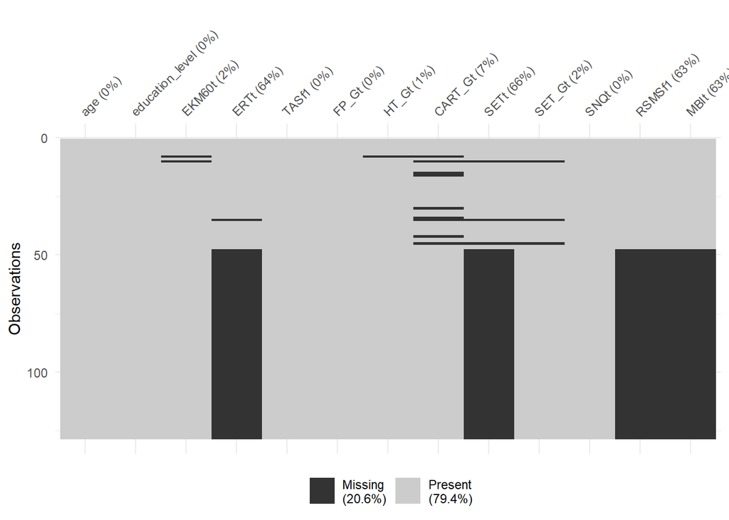

```r
vis_miss(data_pooled[,c("age", "education_level",names_rel_items_abbr)])
```

And the following zero order paired correlation (respectively: corr, N, p-values).

```r
rcorr(as.matrix(data_pooled[, c("age", "education_level",
                                        'EKM60t', 'ERTt', 'TASf1',
                                        'FP_Gt', 'CART_Gt', 'SET_Gt',
                                        'SNQt', 'RSMSf1', 'MBIt')]))
```

```
##                   age education_level EKM60t  ERTt TASf1 FP_Gt CART_Gt SET_Gt
## age              1.00           -0.28  -0.06 -0.42  0.04 -0.10    0.02  -0.20
## education_level -0.28            1.00   0.18  0.45  0.09  0.14    0.34   0.18
## EKM60t          -0.06            0.18   1.00  0.64  0.17  0.30    0.24   0.12
## ERTt            -0.42            0.45   0.64  1.00  0.17  0.35    0.25   0.35
## TASf1            0.04            0.09   0.17  0.17  1.00  0.11    0.02   0.04
## FP_Gt           -0.10            0.14   0.30  0.35  0.11  1.00    0.22   0.18
## CART_Gt          0.02            0.34   0.24  0.25  0.02  0.22    1.00   0.19
## SET_Gt          -0.20            0.18   0.12  0.35  0.04  0.18    0.19   1.00
## SNQt            -0.09            0.26   0.10  0.14  0.06  0.23    0.13   0.10
## RSMSf1          -0.07            0.00   0.29  0.09  0.35  0.24    0.29   0.13
## MBIt             0.33           -0.04   0.13  0.18  0.22  0.01    0.32   0.07
##                  SNQt RSMSf1  MBIt
## age             -0.09  -0.07  0.33
## education_level  0.26   0.00 -0.04
## EKM60t           0.10   0.29  0.13
## ERTt             0.14   0.09  0.18
## TASf1            0.06   0.35  0.22
## FP_Gt            0.23   0.24  0.01
## CART_Gt          0.13   0.29  0.32
## SET_Gt           0.10   0.13  0.07
## SNQt             1.00  -0.14  0.05
## RSMSf1          -0.14   1.00 -0.09
## MBIt             0.05  -0.09  1.00
##
## n
##                 age education_level EKM60t ERTt TASf1 FP_Gt CART_Gt SET_Gt SNQt
## age             128             128    126   46   128   128     119    125  128
## education_level 128             128    126   46   128   128     119    125  128
## EKM60t          126             126    126   44   126   126     119    124  126
## ERTt             46              46     44   46    46    46      38     44   46
## TASf1           128             128    126   46   128   128     119    125  128
## FP_Gt           128             128    126   46   128   128     119    125  128
## CART_Gt         119             119    119   38   119   119     119    119  119
## SET_Gt          125             125    124   44   125   125     119    125  125
## SNQt            128             128    126   46   128   128     119    125  128
## RSMSf1           47              47     45   46    47    47      38     44   47
## MBIt             47              47     45   46    47    47      38     44   47
##                 RSMSf1 MBIt
## age                 47   47
```

[output cut: 21 more lines]

```
## SNQt            0.2871 0.0028          0.2846 0.3457 0.4734 0.0107 0.1681
## RSMSf1          0.6426 0.9846          0.0516 0.5463 0.0161 0.1084 0.0797
## MBIt            0.0233 0.7803          0.3871 0.2414 0.1332 0.9620 0.0490
##                 SET_Gt SNQt   RSMSf1 MBIt
## age             0.0269 0.2871 0.6426 0.0233
## education_level 0.0509 0.0028 0.9846 0.7803
## EKM60t          0.1999 0.2846 0.0516 0.3871
## ERTt            0.0217 0.3457 0.5463 0.2414
## TASf1           0.6607 0.4734 0.0161 0.1332
## FP_Gt           0.0420 0.0107 0.1084 0.9620
## CART_Gt         0.0409 0.1681 0.0797 0.0490
## SET_Gt                 0.2611 0.4116 0.6504
## SNQt            0.2611        0.3499 0.7418
## RSMSf1          0.4116 0.3499        0.5658
## MBIt            0.6504 0.7418 0.5658
```

## Imputation predictor selection

### Predictor selection ERTt

Lets check the correlations of ERTt with other relevant variables.

```r
matcor <- Hmisc:: rcorr(as.matrix(data_pooled[, c("age", "education_level",
                                        'EKM60t', 'ERTt', 'TASf1',
                                        'FP_Gt', 'HT_Gt', 'CART_Gt', 'SET_Gt',
                                        'SNQt', 'RSMSf1', 'MBIt')]))

#Check whether sex is also a significant predictor
sexERTt <- lm(ERTt ~ sex, data = data_pooled)
summary(sexERTt)$coefficients["sex", "Pr(>|t|)"] #Not significant
```

```
## [1] 0.1775048
```

```r
sigpred_ERTt <- matcor$r["ERTt",matcor$P["ERTt",]<.05]; sigpred_ERTt #significant correlations of ERTt
```

```
##             age education_level          EKM60t            <NA>           FP_Gt
##      -0.4211357       0.4526528       0.6353631              NA       0.3468226
##          SET_Gt
##       0.3452348
```

```r
# corrplot(matcor$r, p.mat = matcor$P, sig.level = 0.05, method = "number", type = "lower", tl.col = "black", tl.srt = 45,
#          #insig = "blank",
#          addCoef.col = "black")
```

We will impute the missing ERTt values using predictive mean matching (stochastic) based on the significant predictors.

### Predictor selection RSMSf1

Lets check the correlations of RSMSf1 with other relevant variables.

```r
#Check whether sex is also a significant predictor
sexRSMSf1 <- lm(RSMSf1 ~ sex, data = data_pooled)
summary(sexRSMSf1)$coefficients["sex", "Pr(>|t|)"] #Not significant
```

```
## [1] 0.08581445
```

```r
#Check numerical correlations
sigpred_RSMSf1 <- matcor$r["RSMSf1",matcor$P["RSMSf1",]<.05]; sigpred_RSMSf1 #significant correlations of RSMSf1
```

```
##     TASf1      <NA>
## 0.3494505        NA
```

### Predictor selection MBIt

Lets check the correlations of MBIt with other relevant variables.

```r
#Check whether sex is also a significant predictor
sexMBIt <- lm(MBIt ~ sex, data = data_pooled)
summary(sexMBIt)$coefficients["sex", "Pr(>|t|)"] #Not significant
```

```
## [1] 0.33373
```

```r
#Check numerical correlations
sigpred_MBIt <- matcor$r["MBIt",matcor$P["MBIt",]<.05]; sigpred_MBIt #significant correlations of MBIt
```

```
##       age   CART_Gt      <NA>
## 0.3305121 0.3216157        NA
```

## Imputation of ERTt, RSMSf, MBIt

```r
data_pooled_subset <- data_pooled[,c("ID", "centerID", "sex", "age", "education_level",
                                        'EKM60t', 'ERTt', 'TASf1',
                                        'FP_Gt', 'CART_Gt', 'SET_Gt',
                                        'SNQt', 'RSMSf1', 'MBIt')]

predictor_matrix <- make.predictorMatrix(data_pooled_subset)
predictor_matrix[] <- 0

#assign the significant predictors to the prediction matrix
predictor_matrix["ERTt", ] <- colnames(predictor_matrix) %in% names(sigpred_ERTt)[!is.na(names(sigpred_ERTt))]
predictor_matrix["RSMSf1", ] <- colnames(predictor_matrix) %in% names(sigpred_RSMSf1)[!is.na(names(sigpred_RSMSf1))]
predictor_matrix["MBIt", ] <- colnames(predictor_matrix) %in% names(sigpred_MBIt)[!is.na(names(sigpred_MBIt))]

#assign imputation medhods
imputation_methods <- make.method(data_pooled_subset)
imputation_methods[] <- ""  # Set all methods to "" initially
imputation_methods[c("ERTt", "RSMSf1", "MBIt")] <- "pmm"  # Use "pmm" for ERTt

#imputation
data_pooled_subset_imp <- complete(mice(data_pooled_subset,
                               method = imputation_methods,
                               predictorMatrix = predictor_matrix,
                               m = 1,
                               seed = 42), 1)
```

### Visualisation ERTt impuations

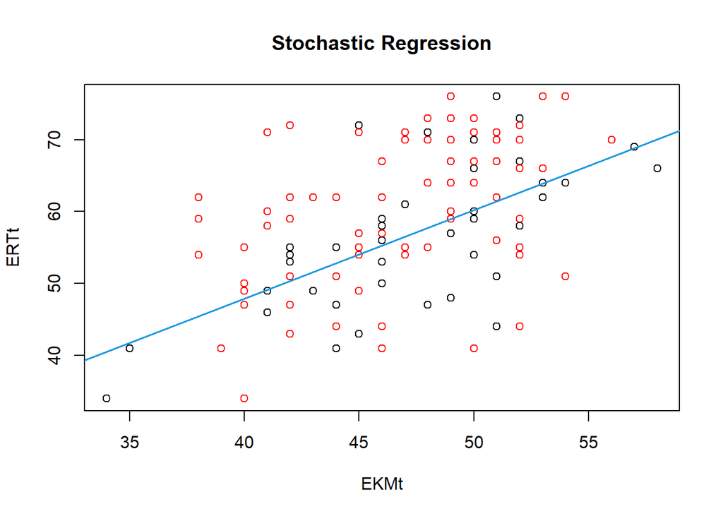

```r
# Stochastic regression imputation plot for ERTt
plot(data_pooled_subset$EKM60t[!is.na(data_pooled_subset$ERTt)], data_pooled_subset_imp$ERTt[!is.na(data_pooled_subset$ERTt)],# Plot of observed values
     main = "Stochastic Regression",
     xlab = "EKMt", ylab = "ERTt")
points(data_pooled_subset$EKM60t[is.na(data_pooled_subset$ERTt)], data_pooled_subset_imp$ERTt[is.na(data_pooled_subset$ERTt)],# Plot of missing values
       col = "red")
abline(lm(data_pooled_subset$ERTt ~ data_pooled_subset$EKM60t, data_pooled_subset_imp), col = "#1b98e0", lwd = 1.5) # Regression slope
```

### Visualisation RSMSf1 impuations

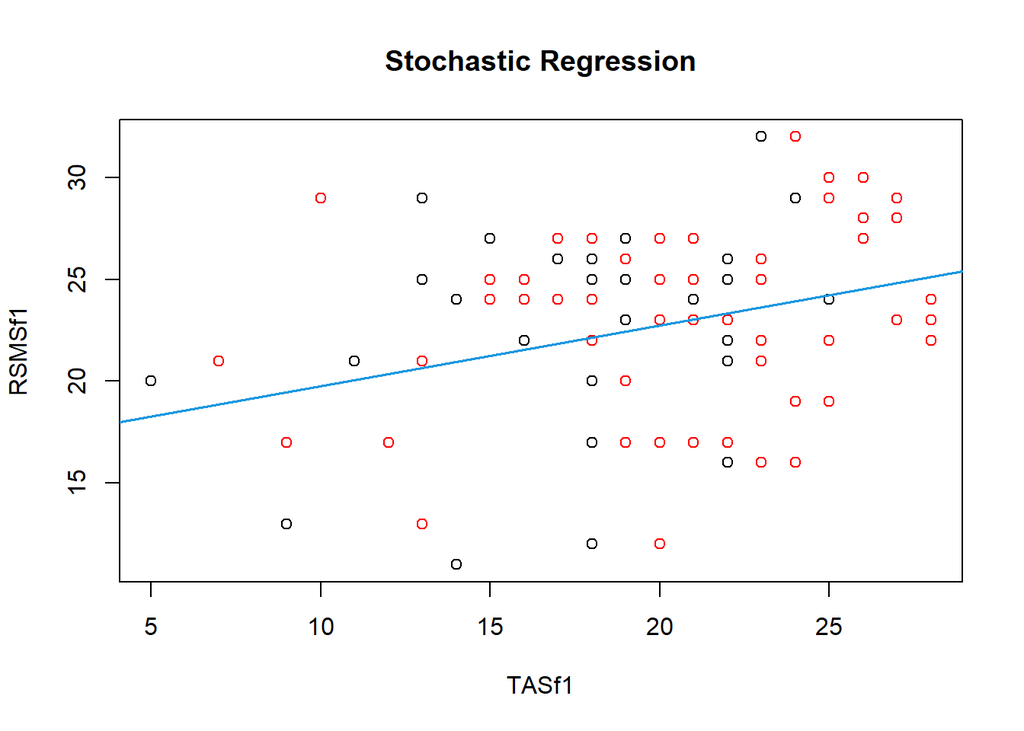

```r
# Stochastic regression imputation plot for RSMSf1
plot(data_pooled_subset$TASf1[!is.na(data_pooled_subset$RSMSf1)], data_pooled_subset_imp$RSMSf1[!is.na(data_pooled_subset$RSMSf1)],# Plot of observed values
     main = "Stochastic Regression",
     xlab = "TASf1", ylab = "RSMSf1")
points(data_pooled_subset$TASf1[is.na(data_pooled_subset$RSMSf1)], data_pooled_subset_imp$RSMSf1[is.na(data_pooled_subset$RSMSf1)],# Plot of missing values
       col = "red")
abline(lm(data_pooled_subset$RSMSf1 ~ data_pooled_subset$TASf1, data_pooled_subset_imp), col = "#1b98e0", lwd = 1.5) # Regression slope
```

### Visualisation MBIt impuations

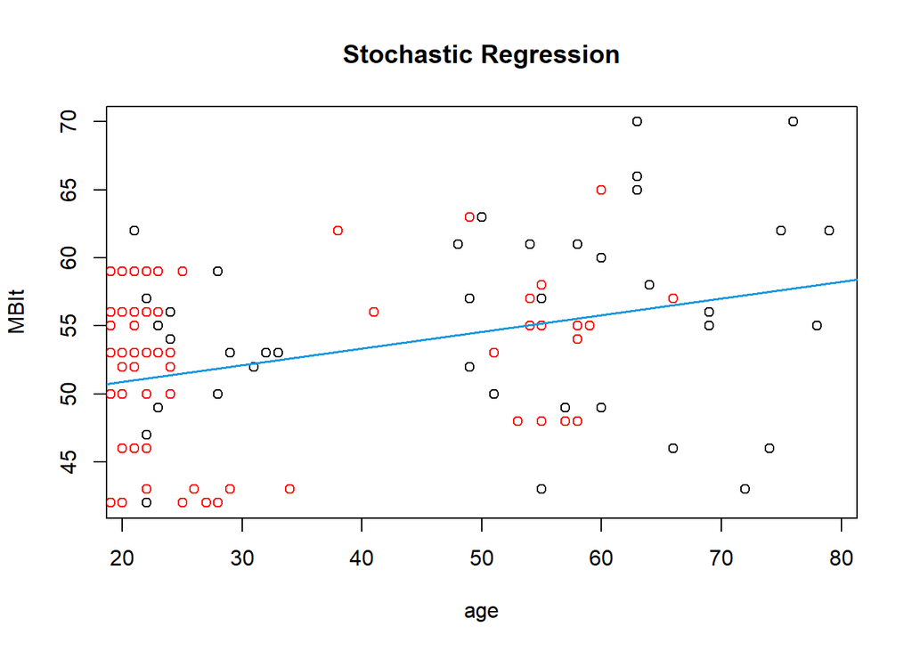

```r
# Stochastic regression imputation plot for MBIt
plot(data_pooled_subset$age[!is.na(data_pooled_subset$MBIt)], data_pooled_subset_imp$MBIt[!is.na(data_pooled_subset$MBIt)],# Plot of observed values
     main = "Stochastic Regression",
     xlab = "age", ylab = "MBIt")
points(data_pooled_subset$age[is.na(data_pooled_subset$MBIt)], data_pooled_subset_imp$MBIt[is.na(data_pooled_subset$MBIt)],# Plot of missing values
       col = "red")
abline(lm(data_pooled_subset$MBIt ~ data_pooled_subset$age, data_pooled_subset_imp), col = "#1b98e0", lwd = 1.5) # Regression slope
```

## Mid term missing data evaluation

At this point, we have the following missing data:

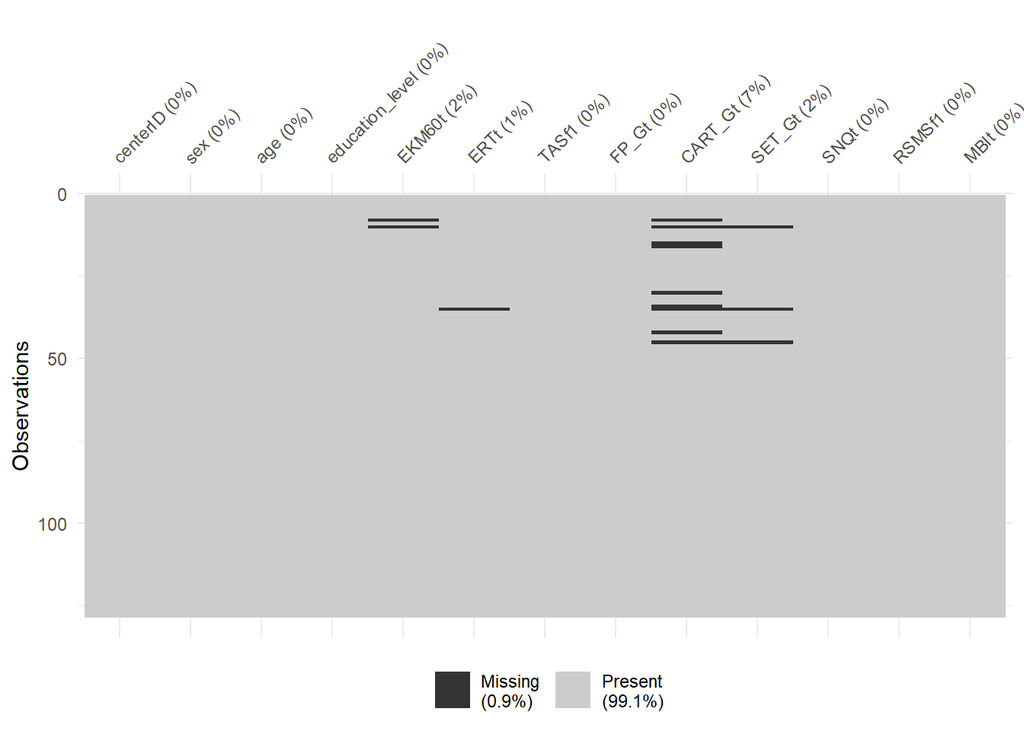

```r
vis_miss(data_pooled_subset_imp[,-1])
```

We will impute the remaining missing values, again with a stochastic approach based on significant correlations or significant t.test for sex.

## Imputation predictor selection part 2

### Predictor selection CART_Gt

Lets check the correlations of CART_Gt with other relevant variables.

```r
matcor2 <- Hmisc:: rcorr(as.matrix(data_pooled_subset_imp[, c("age", "education_level",
                                        'EKM60t', 'ERTt', 'TASf1',
                                        'FP_Gt', 'CART_Gt', 'SET_Gt',
                                        'SNQt', 'RSMSf1', 'MBIt')]))

#Check whether sex is also a significant predictor
sexCART_Gt <- lm(CART_Gt ~ sex, data = data_pooled_subset_imp)
summary(sexCART_Gt)$coefficients["sex", "Pr(>|t|)"] #Significant
```

```
## [1] 0.0005648991
```

```r
sigpred_CART_Gt <- matcor2$r["CART_Gt",matcor2$P["CART_Gt",]<.05]; sigpred_CART_Gt #significant correlations of CART_Gt
```

```
## education_level          EKM60t            ERTt           FP_Gt            <NA>
##       0.3372836       0.2394804       0.2402233       0.2187845              NA
##          SET_Gt          RSMSf1
##       0.1877775       0.2021467
```

```r
sigpred_CART_Gt$sex <- summary(sexCART_Gt)$coefficients["sex", "Pr(>|t|)"] #Significant
```

### Predictor selection SET_Gt

Lets check the correlations of SET_Gt with other relevant variables.

```r
#Check whether sex is also a significant predictor
sexSET_Gt <- lm(SET_Gt ~ sex, data = data_pooled_subset_imp)
summary(sexSET_Gt)$coefficients["sex", "Pr(>|t|)"] #Not ignificant
```

```
## [1] 0.1354767
```

```r
sigpred_SET_Gt <- matcor2$r["SET_Gt",matcor2$P["SET_Gt",]<.05]; sigpred_SET_Gt #significant correlations of SET_Gt
```

```
##        age       ERTt      FP_Gt    CART_Gt       <NA>
## -0.1980193  0.5010054  0.1821579  0.1877775         NA
```

### Predictor selection EKM60t

Lets check the correlations of EKM60t with other relevant variables.

```r
#Check whether sex is also a significant predictor
sexEKM60t <- lm(EKM60t ~ sex, data = data_pooled_subset_imp)
summary(sexEKM60t)$coefficients["sex", "Pr(>|t|)"] #Not significant
```

```
## [1] 0.2449073
```

```r
sigpred_EKM60t <- matcor2$r["EKM60t",matcor2$P["EKM60t",]<.05]; sigpred_EKM60t #significant correlations of EKM60t
```

```
## education_level            <NA>            ERTt           FP_Gt         CART_Gt
##       0.1810381              NA       0.5057871       0.2988278       0.2394804
##          RSMSf1
##       0.1924306
```

### Predictor selection ERTt (second round)

Lets check the correlations of ERTt with other relevant variables.

```r
#Check whether sex is also a significant predictor
sexERTt_2nd <- lm(ERTt ~ sex, data = data_pooled_subset_imp)
summary(sexERTt_2nd)$coefficients["sex", "Pr(>|t|)"] #Not significant
```

```
## [1] 0.7873681
```

```r
sigpred_ERTt_2nd <- matcor2$r["ERTt",matcor2$P["ERTt",]<.05]; sigpred_ERTt_2nd #significant correlations of ERTt
```

```
##             age education_level          EKM60t            <NA>           FP_Gt
##      -0.3202251       0.2671958       0.5057871              NA       0.4173242
##         CART_Gt          SET_Gt
##       0.2402233       0.5010054
```

## Imputation of CART_Gt, SET_Gt, EKM60t, ERTt (2nd imputation round)

```r
data_pooled_subset_imp2 <- data_pooled_subset_imp

predictor_matrix2 <- make.predictorMatrix(data_pooled_subset_imp)
predictor_matrix2[] <- 0

#assign the significant predictors to the prediction matrix
predictor_matrix2["CART_Gt", ] <-
  colnames(predictor_matrix2) %in% names(sigpred_CART_Gt)[!is.na(names(sigpred_CART_Gt))]
predictor_matrix2["SET_Gt", ] <-
  colnames(predictor_matrix2) %in% names(sigpred_SET_Gt)[!is.na(names(sigpred_SET_Gt))]
predictor_matrix2["EKM60t", ] <-
  colnames(predictor_matrix2) %in% names(sigpred_EKM60t)[!is.na(names(sigpred_EKM60t))]
predictor_matrix2["ERTt", ] <-
  colnames(predictor_matrix2) %in% names(sigpred_ERTt_2nd)[!is.na(names(sigpred_ERTt_2nd))]


#assign imputation medhods
imputation_methods2 <- make.method(data_pooled_subset_imp)
imputation_methods2[] <- ""  # Set all methods to "" initially
imputation_methods2[c("CART_Gt", "SET_Gt", "EKM60t", "ERTt")] <- "pmm"  # Use "pmm" for ERTt

#imputation
data_pooled_subset_imp2 <- complete(mice(data_pooled_subset_imp,
                               method = imputation_methods2,
                               predictorMatrix = predictor_matrix2,
                               m = 1,
                               seed = 42), 1)
```

### Check after imputation part 2

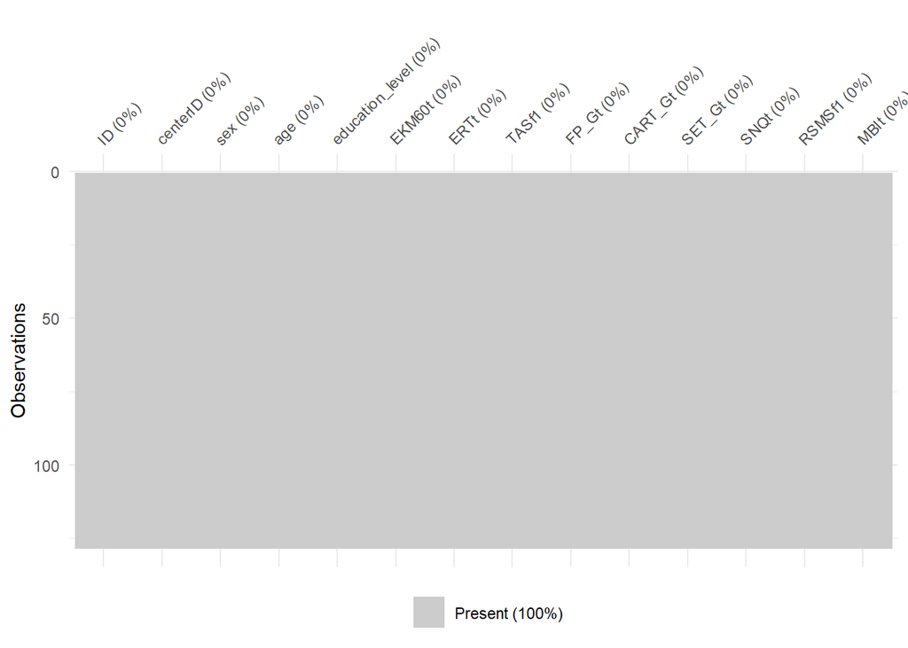

```r
vis_miss(data_pooled_subset_imp2)
```

No missing values anymore

# Final dataset

## Characteristics

```r
data_final <- data_pooled_subset_imp2
data_final <- merge(data_final, data_pooled[,c('ID', 'TQ_total')], by = "ID", all.x = TRUE)
colnames(data_final)[colnames(data_final)=="TQ_total"] <- "TQt"

descriptives_data_final <- psych::describe(data_final[,-1]) %>%
  select(n, min, max, mean, median, sd, skew, kurtosis); descriptives_data_final
```

|  | n | min | max | mean | median | sd | skew | kurtosis |
| --- | --- | --- | --- | --- | --- | --- | --- | --- |
| centerID* | 128 | 1.0 | 2 | 1.632812 | 2 | 0.4839323 | -0.54460059 | -1.71663881 |
| sex | 128 | 0.0 | 1 | 0.640625 | 1 | 0.4817026 | -0.57930501 | -1.67732719 |
| age | 128 | 18.0 | 79 | 35.656250 | 24 | 18.6059162 | 0.74974546 | -1.00307893 |
| education_level | 128 | 2.0 | 7 | 5.906250 | 6 | 0.8270762 | -1.56675018 | 4.69445314 |
| EKM60t | 128 | 34.0 | 58 | 47.164062 | 48 | 4.6563433 | -0.34705722 | -0.27160333 |
| ERTt | 128 | 34.0 | 76 | 59.304688 | 60 | 10.0271746 | -0.34338356 | -0.67793018 |
| TASf1 | 128 | 5.0 | 31 | 20.773438 | 21 | 4.9153701 | -0.71007018 | 0.48957203 |
| FP_Gt | 128 | 10.5 | 24 | 20.312500 | 21 | 2.4179447 | -0.94959250 | 1.31754902 |
| CART_Gt | 128 | 0.0 | 12 | 8.386719 | 9 | 2.5689046 | -0.40812222 | -0.40752968 |
| SET_Gt | 128 | 8.0 | 12 | 11.364724 | 12 | 0.8547326 | -1.52422644 | 2.02901838 |

[output cut: 4 more lines]

```r
corr_data_final <- Hmisc:: rcorr(as.matrix(data_final[,-c(1:2)])); corr_data_final
```

```
##                   sex   age education_level EKM60t  ERTt TASf1 FP_Gt CART_Gt
## sex              1.00 -0.02           -0.14   0.10 -0.03 -0.03 -0.11   -0.35
## age             -0.02  1.00           -0.28  -0.06 -0.32  0.04 -0.10   -0.04
## education_level -0.14 -0.28            1.00   0.18  0.27  0.09  0.14    0.38
## EKM60t           0.10 -0.06            0.18   1.00  0.50  0.16  0.30    0.28
## ERTt            -0.03 -0.32            0.27   0.50  1.00  0.10  0.42    0.25
## TASf1           -0.03  0.04            0.09   0.16  0.10  1.00  0.11    0.01
## FP_Gt           -0.11 -0.10            0.14   0.30  0.42  0.11  1.00    0.26
## CART_Gt         -0.35 -0.04            0.38   0.28  0.25  0.01  0.26    1.00
## SET_Gt          -0.13 -0.18            0.15   0.11  0.50  0.05  0.17    0.19
## SNQt             0.02 -0.09            0.26   0.09  0.09  0.06  0.23    0.12
## RSMSf1          -0.22  0.05           -0.01   0.19  0.01  0.25  0.01    0.21
## MBIt             0.15  0.31            0.05   0.06 -0.07  0.12 -0.07    0.08
## TQt              0.11 -0.05            0.25   0.39  0.26  0.15  0.14    0.25
##                 SET_Gt  SNQt RSMSf1  MBIt   TQt
## sex              -0.13  0.02  -0.22  0.15  0.11
## age              -0.18 -0.09   0.05  0.31 -0.05
## education_level   0.15  0.26  -0.01  0.05  0.25
## EKM60t            0.11  0.09   0.19  0.06  0.39
## ERTt              0.50  0.09   0.01 -0.07  0.26
## TASf1             0.05  0.06   0.25  0.12  0.15
## FP_Gt             0.17  0.23   0.01 -0.07  0.14
## CART_Gt           0.19  0.12   0.21  0.08  0.25
## SET_Gt            1.00  0.10   0.06 -0.05  0.26
## SNQt              0.10  1.00   0.00  0.04 -0.10
## RSMSf1            0.06  0.00   1.00  0.00  0.18
## MBIt             -0.05  0.04   0.00  1.00 -0.10
## TQt               0.26 -0.10   0.18 -0.10  1.00
##
## n
##                 sex age education_level EKM60t ERTt TASf1 FP_Gt CART_Gt SET_Gt
## sex             128 128             128    128  128   128   128     128    128
## age             128 128             128    128  128   128   128     128    128
## education_level 128 128             128    128  128   128   128     128    128
## EKM60t          128 128             128    128  128   128   128     128    128
## ERTt            128 128             128    128  128   128   128     128    128
## TASf1           128 128             128    128  128   128   128     128    128
## FP_Gt           128 128             128    128  128   128   128     128    128
## CART_Gt         128 128             128    128  128   128   128     128    128
## SET_Gt          128 128             128    128  128   128   128     128    128
```

[output cut: 33 more lines]

```
## TQt             0.4532 0.7220 0.0878          0.0069 0.0811 0.3159 0.3399
##                 CART_Gt SET_Gt SNQt   RSMSf1 MBIt   TQt
## sex             0.0000  0.1567 0.8589 0.0121 0.0884 0.4532
## age             0.6772  0.0399 0.2871 0.5607 0.0004 0.7220
## education_level 0.0000  0.0819 0.0028 0.9181 0.5449 0.0878
## EKM60t          0.0015  0.2271 0.3173 0.0304 0.4963 0.0069
## ERTt            0.0052  0.0000 0.3092 0.8924 0.4276 0.0811
## TASf1           0.8905  0.6087 0.4734 0.0046 0.1680 0.3159
## FP_Gt           0.0031  0.0497 0.0107 0.8941 0.4558 0.3399
## CART_Gt                 0.0279 0.1654 0.0158 0.3729 0.0951
## SET_Gt          0.0279         0.2702 0.5180 0.5542 0.0836
## SNQt            0.1654  0.2702        0.9812 0.6244 0.4961
## RSMSf1          0.0158  0.5180 0.9812        0.9830 0.2266
## MBIt            0.3729  0.5542 0.6244 0.9830        0.5206
## TQt             0.0951  0.0836 0.4961 0.2266 0.5206
```

```r
corr_data_final_r <- round(as.data.frame(corr_data_final$r), 3); corr_data_final_r
```

|  | sex | age | education_level | EKM60t | ERTt | TASf1 | FP_Gt | CART_Gt | SET_Gt | SNQt | RSMSf1 | MBIt | TQt |
| --- | --- | --- | --- | --- | --- | --- | --- | --- | --- | --- | --- | --- | --- |
| sex | 1.000 | -0.023 | -0.145 | 0.104 | -0.026 | -0.035 | -0.112 | -0.354 | -0.126 | 0.016 | -0.221 | 0.151 | 0.112 |
| age | -0.023 | 1.000 | -0.277 | -0.056 | -0.320 | 0.040 | -0.099 | -0.037 | -0.182 | -0.095 | 0.052 | 0.306 | -0.053 |
| education_level | -0.145 | -0.277 | 1.000 | 0.182 | 0.267 | 0.094 | 0.143 | 0.379 | 0.154 | 0.262 | -0.009 | 0.054 | 0.252 |
| EKM60t | 0.104 | -0.056 | 0.182 | 1.000 | 0.504 | 0.157 | 0.299 | 0.278 | 0.108 | 0.089 | 0.191 | 0.061 | 0.389 |
| ERTt | -0.026 | -0.320 | 0.267 | 0.504 | 1.000 | 0.099 | 0.418 | 0.245 | 0.500 | 0.091 | 0.012 | -0.071 | 0.257 |
| TASf1 | -0.035 | 0.040 | 0.094 | 0.157 | 0.099 | 1.000 | 0.113 | 0.012 | 0.046 | 0.064 | 0.249 | 0.123 | 0.149 |
| FP_Gt | -0.112 | -0.099 | 0.143 | 0.299 | 0.418 | 0.113 | 1.000 | 0.260 | 0.174 | 0.225 | 0.012 | -0.066 | 0.142 |
| CART_Gt | -0.354 | -0.037 | 0.379 | 0.278 | 0.245 | 0.012 | 0.260 | 1.000 | 0.194 | 0.123 | 0.213 | 0.079 | 0.246 |
| SET_Gt | -0.126 | -0.182 | 0.154 | 0.108 | 0.500 | 0.046 | 0.174 | 0.194 | 1.000 | 0.098 | 0.058 | -0.053 | 0.255 |
| SNQt | 0.016 | -0.095 | 0.262 | 0.089 | 0.091 | 0.064 | 0.225 | 0.123 | 0.098 | 1.000 | -0.002 | 0.044 | -0.102 |

[output cut: 3 more lines]

```r
corr_data_final_P <- round(as.data.frame(corr_data_final$P), 3); corr_data_final_P
```

|  | sex | age | education_level | EKM60t | ERTt | TASf1 | FP_Gt | CART_Gt | SET_Gt | SNQt | RSMSf1 | MBIt | TQt |
| --- | --- | --- | --- | --- | --- | --- | --- | --- | --- | --- | --- | --- | --- |
| sex | NA | 0.799 | 0.104 | 0.244 | 0.770 | 0.698 | 0.207 | 0.000 | 0.157 | 0.859 | 0.012 | 0.088 | 0.453 |
| age | 0.799 | NA | 0.002 | 0.529 | 0.000 | 0.654 | 0.267 | 0.677 | 0.040 | 0.287 | 0.561 | 0.000 | 0.722 |
| education_level | 0.104 | 0.002 | NA | 0.040 | 0.002 | 0.294 | 0.108 | 0.000 | 0.082 | 0.003 | 0.918 | 0.545 | 0.088 |
| EKM60t | 0.244 | 0.529 | 0.040 | NA | 0.000 | 0.076 | 0.001 | 0.001 | 0.227 | 0.317 | 0.030 | 0.496 | 0.007 |
| ERTt | 0.770 | 0.000 | 0.002 | 0.000 | NA | 0.265 | 0.000 | 0.005 | 0.000 | 0.309 | 0.892 | 0.428 | 0.081 |
| TASf1 | 0.698 | 0.654 | 0.294 | 0.076 | 0.265 | NA | 0.205 | 0.890 | 0.609 | 0.473 | 0.005 | 0.168 | 0.316 |
| FP_Gt | 0.207 | 0.267 | 0.108 | 0.001 | 0.000 | 0.205 | NA | 0.003 | 0.050 | 0.011 | 0.894 | 0.456 | 0.340 |
| CART_Gt | 0.000 | 0.677 | 0.000 | 0.001 | 0.005 | 0.890 | 0.003 | NA | 0.028 | 0.165 | 0.016 | 0.373 | 0.095 |
| SET_Gt | 0.157 | 0.040 | 0.082 | 0.227 | 0.000 | 0.609 | 0.050 | 0.028 | NA | 0.270 | 0.518 | 0.554 | 0.084 |
| SNQt | 0.859 | 0.287 | 0.003 | 0.317 | 0.309 | 0.473 | 0.011 | 0.165 | 0.270 | NA | 0.981 | 0.624 | 0.496 |

[output cut: 3 more lines]

```r
#knitr::kable(corr_data_final_r, format = "latex", booktabs = TRUE, caption = "Correlation matrix final dataset")
#knitr::kable(corr_data_final_P, format = "latex", booktabs = TRUE, caption = "P-values corresponding to the correlations")
```

## Z-scores

```r
names_items_analysis <- c("EKM60t", "ERTt", "TASf1", "CART_Gt", "FP_Gt", "SET_Gt", "SNQt", "MBIt", "RSMSf1")
data_final_Z <- cbind(data_final[, c("ID", "centerID", names_covariates)], round(scale(data_final[, c(names_items_analysis, 'TQt')]), 4))
```

# Analyses

## CFA models

```r
#full 3 factor model
m1_f3fm <- '
# Defining the factors (latent variables)
f1_P =~ EKM60t + ERTt + TASf1
f2_U =~ SET_Gt + FP_Gt + CART_Gt
f3_BR =~ RSMSf1 + SNQt + MBIt

# Allow factors to be correlated
f1_P ~~ f2_U
f1_P ~~ f3_BR
f2_U ~~ f3_BR
'

#two factor model: f1 = f2
m2_2fm_1eq2 <- '
# Defining the factors (latent variables)
f1_P =~ EKM60t + ERTt + TASf1
f2_U =~ SET_Gt + FP_Gt + CART_Gt
f3_BR =~ RSMSf1 + SNQt + MBIt

# Allow factors to be correlated
f1_P ~~ 1*f2_U  # Fix correlation between f1_P and f2_U at 1
f1_P ~~ f3_BR
f2_U ~~ f3_BR
'

#model 3: two factor model: f1 = f3 (CART)
m3_2fm_1eq3 <- '
# Defining the factors (latent variables)
f1_P =~ EKM60t + ERTt + TASf1
f2_U =~ SET_Gt + FP_Gt + CART_Gt
f3_BR =~ RSMSf1 + SNQt + MBIt

# Allow factors to be correlated
f1_P ~~ f2_U
f1_P ~~ 1*f3_BR # Fix correlation between f1_P and f3_BR at 1
f2_U ~~ f3_BR
'

#model 4: two factor model: f2 = f3 (CART)
m4_2fm_2eq3 <- '
# Defining the factors (latent variables)
f1_P =~ EKM60t + ERTt + TASf1
f2_U =~ SET_Gt + FP_Gt + CART_Gt
f3_BR =~ RSMSf1 + SNQt + MBIt

# Allow factors to be correlated
f1_P ~~ f2_U
f1_P ~~ f3_BR
f2_U ~~ 1*f3_BR # Fix correlation between f2_U and f3_BR at 1
'

#model 5: one fact0r model: f1 = f2 = f3 (CART)
m5_1fm <- '
# Defining the factors (latent variables)
f1_P =~ EKM60t + ERTt + TASf1
f2_U =~ SET_Gt + FP_Gt + CART_Gt
f3_BR =~ RSMSf1 + SNQt + MBIt

# Fixing all interfactor correlations at 1
f1_P ~~ 1*f2_U
f1_P ~~ 1*f3_BR
f2_U ~~ 1*f3_BR
'

#model 6: 3 one facter model: independent factors (CART)
m6_3x1fm <- '
# Defining the factors (latent variables)
f1_P =~ EKM60t + ERTt + TASf1
f2_U =~ SET_Gt + FP_Gt + CART_Gt
f3_BR =~ RSMSf1 + SNQt + MBIt

# Fixing all interfactor correlations at 0
f1_P ~~ 0*f2_U
f1_P ~~ 0*f3_BR
f2_U ~~ 0*f3_BR
'
```

## CFA EMC data (N=47)

```r
#model 1; EMC data
fit_m1_EMC <- cfa(model = m1_f3fm, data = data_final_Z[data_final_Z$centerID == "EMC",])
summ_m1_EMC <- summary(fit_m1_EMC, standardized = TRUE, fit.measures = TRUE)
fm_m1_EMC <- fitMeasures(fit_m1_EMC, c("npar", "chisq", "df", "pvalue", "aic", "srmr", "cfi", "ifi", "nfi", "rmsea", "bic"))
```

```r
#model 2; EMC data
fit_m2_EMC <- cfa(model = m2_2fm_1eq2, data = data_final_Z[data_final_Z$centerID == "EMC",])
summ_m2_EMC <- summary(fit_m2_EMC, standardized = TRUE, fit.measures = TRUE)
fm_m2_EMC <- fitMeasures(fit_m2_EMC, c("npar", "chisq", "df", "pvalue", "aic", "srmr", "cfi", "ifi", "nfi", "rmsea", "bic"))
```

```r
#model 3; EMC data
fit_m3_EMC <- cfa(model = m3_2fm_1eq3, data = data_final_Z[data_final_Z$centerID == "EMC",])
summ_m3_EMC <- summary(fit_m3_EMC, standardized = TRUE, fit.measures = TRUE)
fm_m3_EMC <- fitMeasures(fit_m3_EMC, c("npar", "chisq", "df", "pvalue", "aic", "srmr", "cfi", "ifi", "nfi", "rmsea", "bic"))
```

```r
#model 4; EMC data
fit_m4_EMC <- cfa(model = m4_2fm_2eq3, data = data_final_Z[data_final_Z$centerID == "EMC",])
summ_m4_EMC <- summary(fit_m4_EMC, standardized = TRUE, fit.measures = TRUE)
fm_m4_EMC <- fitMeasures(fit_m4_EMC, c("npar", "chisq", "df", "pvalue", "aic", "srmr", "cfi", "ifi", "nfi", "rmsea", "bic"))
```

```r
#model 5; EMC data
fit_m5_EMC <- cfa(model = m5_1fm, data = data_final_Z[data_final_Z$centerID == "EMC",])
summ_m5_EMC <- summary(fit_m5_EMC, standardized = TRUE, fit.measures = TRUE)
fm_m5_EMC <- fitMeasures(fit_m5_EMC, c("npar", "chisq", "df", "pvalue", "aic", "srmr", "cfi", "ifi", "nfi", "rmsea", "bic"))
```

```r
# #model 6; EMC data
# fit_m6_EMC <- cfa(model = m6_3x1fm, data = data_final_Z[data_final_Z$centerID == "EMC",])
# summ_m6_EMC <- summary(fit_m6_EMC, standardized = TRUE, fit.measures = TRUE)
# fm_m6_EMC <- fitMeasures(fit_m6_EMC, c("npar", "chisq", "df", "pvalue", "aic", "srmr", "cfi", "ifi", "nfi", "rmsea", "bic"))
```

## CFA pooled data (N=128)

```r
#model 1; pooled data
fit_m1_pld <- cfa(model = m1_f3fm, data = data_final_Z)
summ_m1_pld <- summary(fit_m1_pld, standardized = TRUE, fit.measures = TRUE)
fm_m1_pld <- fitMeasures(fit_m1_pld, c("npar", "chisq", "df", "pvalue", "aic", "srmr", "cfi", "ifi", "nfi", "rmsea", "bic"))
```

```r
#model 2; pooled data
fit_m2_pld <- cfa(model = m2_2fm_1eq2, data = data_final_Z)
summ_m2_pld <- summary(fit_m2_pld, standardized = TRUE, fit.measures = TRUE)
fm_m2_pld <- fitMeasures(fit_m2_pld, c("npar", "chisq", "df", "pvalue", "aic", "srmr", "cfi", "ifi", "nfi", "rmsea", "bic"))
```

```r
#model 3; pooled data
fit_m3_pld <- cfa(model = m3_2fm_1eq3, data = data_final_Z)
summ_m3_pld <- summary(fit_m3_pld, standardized = TRUE, fit.measures = TRUE)
fm_m3_pld <- fitMeasures(fit_m3_pld, c("npar", "chisq", "df", "pvalue", "aic", "srmr", "cfi", "ifi", "nfi", "rmsea", "bic"))
```

```r
#model 4; pooled data
fit_m4_pld <- cfa(model = m4_2fm_2eq3, data = data_final_Z)
summ_m4_pld <- summary(fit_m4_pld, standardized = TRUE, fit.measures = TRUE)
fm_m4_pld <- fitMeasures(fit_m4_pld, c("npar", "chisq", "df", "pvalue", "aic", "srmr", "cfi", "ifi", "nfi", "rmsea", "bic"))
```

```r
#model 5; pooled data
fit_m5_pld <- cfa(model = m5_1fm, data = data_final_Z)
summ_m5_pld <- summary(fit_m5_pld, standardized = TRUE, fit.measures = TRUE)
fm_m5_pld <- fitMeasures(fit_m5_pld, c("npar", "chisq", "df", "pvalue", "aic", "srmr", "cfi", "ifi", "nfi", "rmsea", "bic"))
```

```r
#model 6; pooled data
fit_m6_pld <- cfa(model = m6_3x1fm, data = data_final_Z)
summ_m6_pld <- summary(fit_m6_pld, standardized = TRUE, fit.measures = TRUE)
fm_m6_pld <- fitMeasures(fit_m6_pld, c("npar", "chisq", "df", "pvalue", "aic", "srmr", "cfi", "ifi", "nfi", "rmsea", "bic"))
```

## SEM models

```r
#3 paths model
#full 3 factor model
sem1 <- '
# Defining the factors (latent variables)
f1_P =~ EKM60t + ERTt + TASf1
f2_U =~ SET_Gt + FP_Gt + CART_Gt
f3_BR =~ RSMSf1 + SNQt + MBIt

#regression
TQt ~ f1_P + f2_U + f3_BR

# Allow factors to be correlated
f1_P ~~ f2_U
f1_P ~~ f3_BR
f2_U ~~ f3_BR
'

#2 path models
#path P->TQ=0
sem2 <- '
# Defining the factors (latent variables)
f1_P =~ EKM60t + ERTt + TASf1
f2_U =~ SET_Gt + FP_Gt + CART_Gt
f3_BR =~ RSMSf1 + SNQt + MBIt

#regression
TQt ~ 0*f1_P + f2_U + f3_BR

# Allow factors to be correlated
f1_P ~~ f2_U
f1_P ~~ f3_BR
f2_U ~~ f3_BR
'

#path U->TQ=0
sem3 <- '
# Defining the factors (latent variables)
f1_P =~ EKM60t + ERTt + TASf1
f2_U =~ SET_Gt + FP_Gt + CART_Gt
f3_BR =~ RSMSf1 + SNQt + MBIt

#regression
TQt ~ f1_P + 0*f2_U + f3_BR

# Allow factors to be correlated
f1_P ~~ f2_U
f1_P ~~ f3_BR
f2_U ~~ f3_BR
'

#path BR->TQ=0
sem4 <- '
# Defining the factors (latent variables)
f1_P =~ EKM60t + ERTt + TASf1
f2_U =~ SET_Gt + FP_Gt + CART_Gt
f3_BR =~ RSMSf1 + SNQt + MBIt

#regression
TQt ~ f1_P + f2_U + 0*f3_BR

# Allow factors to be correlated
f1_P ~~ f2_U
f1_P ~~ f3_BR
f2_U ~~ f3_BR
'


#1 path models
#only path P
sem5 <- '
# Defining the factors (latent variables)
f1_P =~ EKM60t + ERTt + TASf1
f2_U =~ SET_Gt + FP_Gt + CART_Gt
f3_BR =~ RSMSf1 + SNQt + MBIt

#regression
TQt ~ f1_P + 0*f2_U + 0*f3_BR

# Allow factors to be correlated
f1_P ~~ f2_U
f1_P ~~ f3_BR
f2_U ~~ f3_BR
'

#only path U
sem6 <- '
# Defining the factors (latent variables)
f1_P =~ EKM60t + ERTt + TASf1
f2_U =~ SET_Gt + FP_Gt + CART_Gt
f3_BR =~ RSMSf1 + SNQt + MBIt

#regression
TQt ~ 0*f1_P + f2_U + 0*f3_BR

# Allow factors to be correlated
f1_P ~~ f2_U
f1_P ~~ f3_BR
f2_U ~~ f3_BR
'

#only path BR
sem7 <- '
# Defining the factors (latent variables)
f1_P =~ EKM60t + ERTt + TASf1
f2_U =~ SET_Gt + FP_Gt + CART_Gt
f3_BR =~ RSMSf1 + SNQt + MBIt

#regression
TQt ~ 0*f1_P + 0*f2_U + f3_BR

# Allow factors to be correlated
f1_P ~~ f2_U
f1_P ~~ f3_BR
f2_U ~~ f3_BR
'


#no path model (baseline)
sem8 <- '
# Defining the factors (latent variables)
f1_P =~ EKM60t + ERTt + TASf1
f2_U =~ SET_Gt + FP_Gt + CART_Gt
f3_BR =~ RSMSf1 + SNQt + MBIt

#regression
TQt ~ 0*f1_P + 0*f2_U + 0*f3_BR

# Allow factors to be correlated
f1_P ~~ f2_U
f1_P ~~ f3_BR
f2_U ~~ f3_BR
'
```

## SEM EMC data (N=47)

```r
#3 paths model
fit_sem1 <- sem(model = sem1, data = data_final_Z[data_final_Z$centerID == 'EMC',])
summ_sem1 <- summary(fit_sem1, standardized = TRUE, fit.measures = TRUE)
fm_sem1 <- fitMeasures(fit_sem1, c("npar", "chisq", "df", "pvalue", "aic", "srmr", "cfi", "ifi", "nfi", "rmsea", "bic"))
stcoef_sem1 <- standardizedSolution(fit_sem1)[10:12,1:7]

#2 path models
fit_sem2 <- sem(model = sem2, data = data_final_Z[data_final_Z$centerID == 'EMC',])
summ_sem2 <- summary(fit_sem2, standardized = TRUE, fit.measures = TRUE)
fm_sem2 <- fitMeasures(fit_sem2, c("npar", "chisq", "df", "pvalue", "aic", "srmr", "cfi", "ifi", "nfi", "rmsea", "bic"))
stcoef_sem2 <- standardizedSolution(fit_sem2)[10:12,1:7]


fit_sem3 <- sem(model = sem3, data = data_final_Z[data_final_Z$centerID == 'EMC',])
summ_sem3 <- summary(fit_sem3, standardized = TRUE, fit.measures = TRUE)
fm_sem3 <- fitMeasures(fit_sem3, c("npar", "chisq", "df", "pvalue", "aic", "srmr", "cfi", "ifi", "nfi", "rmsea", "bic"))
stcoef_sem3 <- standardizedSolution(fit_sem3)[10:12,1:7]


fit_sem4 <- sem(model = sem4, data = data_final_Z[data_final_Z$centerID == 'EMC',])
summ_sem4 <- summary(fit_sem4, standardized = TRUE, fit.measures = TRUE)
fm_sem4 <- fitMeasures(fit_sem4, c("npar", "chisq", "df", "pvalue", "aic", "srmr", "cfi", "ifi", "nfi", "rmsea", "bic"))
stcoef_sem4 <- standardizedSolution(fit_sem4)[10:12,1:7]


#1 path models
fit_sem5 <- sem(model = sem5, data = data_final_Z[data_final_Z$centerID == 'EMC',])
summ_sem5 <- summary(fit_sem5, standardized = TRUE, fit.measures = TRUE)
fm_sem5 <- fitMeasures(fit_sem5, c("npar", "chisq", "df", "pvalue", "aic", "srmr", "cfi", "ifi", "nfi", "rmsea", "bic"))
stcoef_sem5 <- standardizedSolution(fit_sem5)[10:12,1:7]


fit_sem6 <- sem(model = sem6, data = data_final_Z[data_final_Z$centerID == 'EMC',])
summ_sem6 <- summary(fit_sem6, standardized = TRUE, fit.measures = TRUE)
fm_sem6 <- fitMeasures(fit_sem6, c("npar", "chisq", "df", "pvalue", "aic", "srmr", "cfi", "ifi", "nfi", "rmsea", "bic"))
stcoef_sem6 <- standardizedSolution(fit_sem6)[10:12,1:7]


fit_sem7 <- sem(model = sem7, data = data_final_Z[data_final_Z$centerID == 'EMC',])
summ_sem7 <- summary(fit_sem7, standardized = TRUE, fit.measures = TRUE)
fm_sem7 <- fitMeasures(fit_sem7, c("npar", "chisq", "df", "pvalue", "aic", "srmr", "cfi", "ifi", "nfi", "rmsea", "bic"))
stcoef_sem7 <- standardizedSolution(fit_sem7)[10:12,1:7]


#no path model
fit_sem8 <- sem(model = sem8, data = data_final_Z[data_final_Z$centerID == 'EMC',])
summ_sem8 <- summary(fit_sem8, standardized = TRUE, fit.measures = TRUE)
fm_sem8 <- fitMeasures(fit_sem8, c("npar", "chisq", "df", "pvalue", "aic", "srmr", "cfi", "ifi", "nfi", "rmsea", "bic"))
stcoef_sem8 <- standardizedSolution(fit_sem8)[10:12,1:7]
```

# Results

## CFA EMC data

### Fit indices

```r
results_CFA_EMC <- data.frame(round(rbind(fm_m1_EMC, fm_m2_EMC, fm_m3_EMC, fm_m4_EMC, fm_m5_EMC
                                          #, fm_m6_EMC
                                          ), 3))
modelNames_CFA <- c("Full three-factor", "Two-factor: P = U", "Two-factor: P = BR", "Two-factor: U = BR", "One-factor: P = U = BR"
                    #, "Independent three factor"
                    )
rownames(results_CFA_EMC) <- NULL
results_CFA_EMC <- cbind(Model = modelNames_CFA, results_CFA_EMC)
results_CFA_EMC
```

| Model | npar | chisq | df | pvalue | aic | srmr | cfi | ifi | nfi | rmsea | bic |
| --- | --- | --- | --- | --- | --- | --- | --- | --- | --- | --- | --- |
| Full three-factor | 21 | 25.952 | 24 | 0.356 | 1176.076 | 0.084 | 0.962 | 0.969 | 0.705 | 0.042 | 1214.929 |
| Two-factor: P = U | 20 | 43.386 | 25 | 0.013 | 1191.510 | 0.374 | 0.646 | 0.708 | 0.506 | 0.125 | 1228.513 |
| Two-factor: P = BR | 20 | 35.310 | 25 | 0.083 | 1183.434 | 0.248 | 0.801 | 0.836 | 0.598 | 0.094 | 1220.437 |
| Two-factor: U = BR | 20 | 49.263 | 25 | 0.003 | 1197.387 | 0.432 | 0.532 | 0.614 | 0.439 | 0.144 | 1234.390 |
| One-factor: P = U = BR | 18 | 50.079 | 27 | 0.004 | 1194.204 | 0.464 | 0.555 | 0.621 | 0.430 | 0.135 | 1227.506 |

### Model comparisson

```r
anova(fit_m1_EMC, fit_m2_EMC)
```

|  | Df | AIC | BIC | Chisq | Chisq diff | RMSEA | Df diff | Pr(>Chisq) |
| --- | --- | --- | --- | --- | --- | --- | --- | --- |
| fit_m1_EMC | 24 | 1176.076 | 1214.929 | 25.95179 | NA | NA | NA | NA |
| fit_m2_EMC | 25 | 1191.510 | 1228.513 | 43.38608 | 17.43429 | 0.5913253 | 1 | 2.974128e-05 |

```r
anova(fit_m1_EMC, fit_m3_EMC)
```

|  | Df | AIC | BIC | Chisq | Chisq diff | RMSEA | Df diff | Pr(>Chisq) |
| --- | --- | --- | --- | --- | --- | --- | --- | --- |
| fit_m1_EMC | 24 | 1176.076 | 1214.929 | 25.95179 | NA | NA | NA | NA |
| fit_m3_EMC | 25 | 1183.434 | 1220.437 | 35.30962 | 9.357831 | 0.4216944 | 1 | 0.002220348 |

```r
anova(fit_m1_EMC, fit_m4_EMC)
```

|  | Df | AIC | BIC | Chisq | Chisq diff | RMSEA | Df diff | Pr(>Chisq) |
| --- | --- | --- | --- | --- | --- | --- | --- | --- |
| fit_m1_EMC | 24 | 1176.076 | 1214.929 | 25.95179 | NA | NA | NA | NA |
| fit_m4_EMC | 25 | 1197.387 | 1234.390 | 49.26260 | 23.31081 | 0.6889834 | 1 | 1.378233e-06 |

```r
anova(fit_m1_EMC, fit_m5_EMC)
```

|  | Df | AIC | BIC | Chisq | Chisq diff | RMSEA | Df diff | Pr(>Chisq) |
| --- | --- | --- | --- | --- | --- | --- | --- | --- |
| fit_m1_EMC | 24 | 1176.076 | 1214.929 | 25.95179 | NA | NA | NA | NA |
| fit_m5_EMC | 27 | 1194.204 | 1227.506 | 50.07932 | 24.12752 | 0.3870925 | 3 | 2.349448e-05 |

```r
#anova(fit_m1_EMC, fit_m6_EMC)
```

### Favoured model

```r
stcoefs_fav_CFA_EMC <- standardizedSolution(fit_m1_EMC)
nice_table(stcoefs_fav_CFA_EMC)
```

| lhs | op | rhs | est.std | se | z | p | ci.lower | ci.upper |
| --- | --- | --- | --- | --- | --- | --- | --- | --- |
| f1_P | =~ | EKM60t | 0.90 | 0.11 | 8.49 | < .001*** | 0.69 | 1.11 |
| f1_P | =~ | ERTt | 0.69 | 0.11 | 6.22 | < .001*** | 0.47 | 0.90 |
| f1_P | =~ | TASf1 | 0.27 | 0.15 | 1.79 | .074 | -0.03 | 0.56 |
| f2_U | =~ | SET_Gt | 0.24 | 0.16 | 1.48 | .139 | -0.08 | 0.56 |
| f2_U | =~ | FP_Gt | 0.64 | 0.13 | 5.12 | < .001*** | 0.40 | 0.89 |
| f2_U | =~ | CART_Gt | 0.67 | 0.12 | 5.36 | < .001*** | 0.42 | 0.91 |
| f3_BR | =~ | RSMSf1 |  |  |  |  |  |  |
| f3_BR | =~ | SNQt |  |  |  |  |  |  |
| f3_BR | =~ | MBIt |  |  |  |  |  |  |
| f1_P | ~~ | f2_U | 0.72 | 0.15 | 4.74 | < .001*** | 0.42 | 1.02 |
| f1_P | ~~ | f3_BR | 0.55 | 0.46 | 1.19 | .234 | -0.36 | 1.45 |
| f2_U | ~~ | f3_BR | 0.78 | 0.62 | 1.26 | .208 | -0.43 | 2.00 |
| EKM60t | ~~ | EKM60t | 0.19 | 0.19 | 0.97 | .333 | -0.19 | 0.56 |
| ERTt | ~~ | ERTt | 0.53 | 0.15 | 3.49 | < .001*** | 0.23 | 0.83 |
| TASf1 | ~~ | TASf1 | 0.93 | 0.08 | 11.75 | < .001*** | 0.77 | 1.08 |
| SET_Gt | ~~ | SET_Gt | 0.94 | 0.08 | 12.01 | < .001*** | 0.79 | 1.10 |
| FP_Gt | ~~ | FP_Gt | 0.59 | 0.16 | 3.63 | < .001*** | 0.27 | 0.90 |
| CART_Gt | ~~ | CART_Gt | 0.55 | 0.17 | 3.32 | .001*** | 0.23 | 0.88 |
| RSMSf1 | ~~ | RSMSf1 | 1.31 | 0.48 | 2.71 | .007** | 0.36 | 2.25 |
| SNQt | ~~ | SNQt | 1.04 | 0.06 | 18.30 | < .001*** | 0.93 | 1.15 |
| MBIt | ~~ | MBIt | 1.02 | 0.04 | 25.44 | < .001*** | 0.94 | 1.10 |
| f1_P | ~~ | f1_P | 1.00 | 0.00 |  |  | 1.00 | 1.00 |
| f2_U | ~~ | f2_U | 1.00 | 0.00 |  |  | 1.00 | 1.00 |
| f3_BR | ~~ | f3_BR |  |  |  |  |  |  |

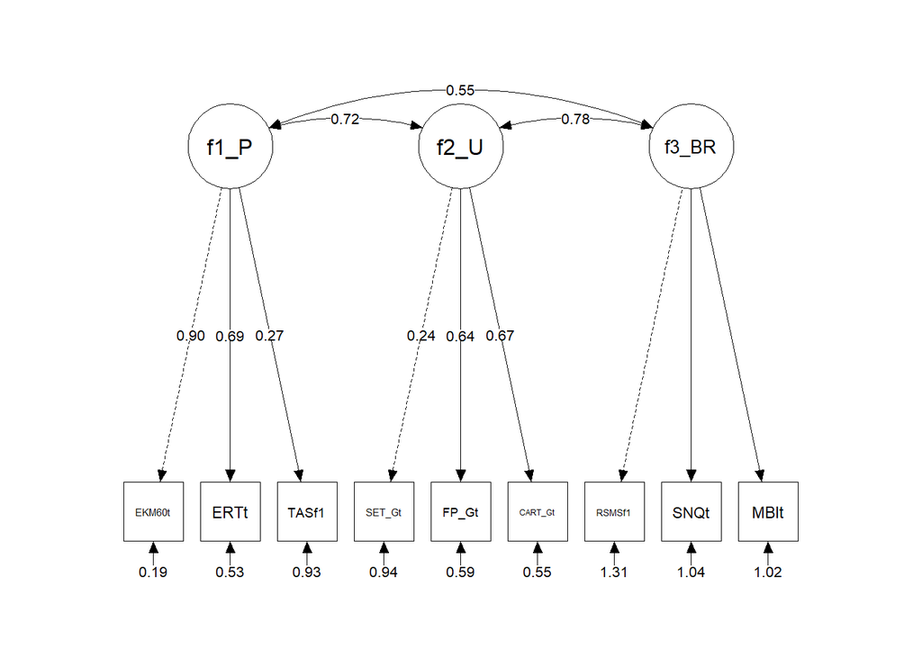

```r
#print(nice_table(stcoefs_fav_CFA_EMC), preview = "docx") #Word format output
semPaths(fit_m1_EMC,
         whatLabels = "std",  # Display standardized estimates
         layout = "tree2",      # Choose a layout, "tree" is one option
         style = "lisrel",     # Style for the diagram
         nCharNodes = 0,       # Full variable names
         sizeMan = 7,          # Size of manifest variables
         sizeLat = 10,         # Size of latent variables
         edge.label.cex = 0.75, # Adjust the size of the edge labels
         label.cex = 0.8,      # Adjust the size of the node labels
         residuals = TRUE,     # Show residuals
         intercepts = FALSE,   # Hide intercepts
         thresholds = FALSE,
         fade = FALSE,
         edge.color = "black"
         )
```

## CFA pooled data

### Fit indices

```r
results_CFA_pld <- data.frame(round(rbind(fm_m1_pld, fm_m2_pld, fm_m3_pld, fm_m4_pld, fm_m5_pld, fm_m6_pld), 3))
modelNames_CFA <- c("Full three-factor", "Two-factor: P = U", "Two-factor: P = BR", "Two-factor: U = BR", "One-factor: P = U = BR", "Independent three factor")
rownames(results_CFA_pld) <- NULL
results_CFA_pld <- cbind(Model = modelNames_CFA, results_CFA_pld)
results_CFA_pld
```

| Model | npar | chisq | df | pvalue | aic | srmr | cfi | ifi | nfi | rmsea | bic |
| --- | --- | --- | --- | --- | --- | --- | --- | --- | --- | --- | --- |
| Full three-factor | 21 | 45.363 | 24 | 0.005 | 3185.383 | 0.075 | 0.831 | 0.845 | 0.720 | 0.083 | 3245.275 |
| Two-factor: P = U | 20 | 80.179 | 25 | 0.000 | 3218.199 | 0.298 | 0.563 | 0.598 | 0.506 | 0.131 | 3275.239 |
| Two-factor: P = BR | 20 | 106.314 | 25 | 0.000 | 3244.334 | 0.317 | 0.356 | 0.407 | 0.344 | 0.159 | 3301.374 |
| Two-factor: U = BR | 20 | 95.357 | 25 | 0.000 | 3233.377 | 0.294 | 0.442 | 0.487 | 0.412 | 0.148 | 3290.417 |
| One-factor: P = U = BR | 18 | 116.076 | 27 | 0.000 | 3250.096 | 0.457 | 0.294 | 0.341 | 0.284 | 0.161 | 3301.432 |
| Independent three factor | 18 | 105.401 | 27 | 0.000 | 3239.420 | 0.146 | 0.379 | 0.420 | 0.350 | 0.151 | 3290.757 |

### Model comparisson

```r
anova(fit_m1_pld, fit_m2_pld)
```

|  | Df | AIC | BIC | Chisq | Chisq diff | RMSEA | Df diff | Pr(>Chisq) |
| --- | --- | --- | --- | --- | --- | --- | --- | --- |
| fit_m1_pld | 24 | 3185.383 | 3245.275 | 45.36310 | NA | NA | NA | NA |
| fit_m2_pld | 25 | 3218.199 | 3275.239 | 80.17917 | 34.81607 | 0.5139923 | 1 | 3.623695e-09 |

```r
anova(fit_m1_pld, fit_m3_pld)
```

|  | Df | AIC | BIC | Chisq | Chisq diff | RMSEA | Df diff | Pr(>Chisq) |
| --- | --- | --- | --- | --- | --- | --- | --- | --- |
| fit_m1_pld | 24 | 3185.383 | 3245.275 | 45.3631 | NA | NA | NA | NA |
| fit_m3_pld | 25 | 3244.334 | 3301.374 | 106.3144 | 60.95128 | 0.6843752 | 1 | 5.850491e-15 |

```r
anova(fit_m1_pld, fit_m4_pld)
```

|  | Df | AIC | BIC | Chisq | Chisq diff | RMSEA | Df diff | Pr(>Chisq) |
| --- | --- | --- | --- | --- | --- | --- | --- | --- |
| fit_m1_pld | 24 | 3185.383 | 3245.275 | 45.36310 | NA | NA | NA | NA |
| fit_m4_pld | 25 | 3233.377 | 3290.417 | 95.35723 | 49.99413 | 0.6186814 | 1 | 1.542064e-12 |

```r
anova(fit_m1_pld, fit_m5_pld)
```

|  | Df | AIC | BIC | Chisq | Chisq diff | RMSEA | Df diff | Pr(>Chisq) |
| --- | --- | --- | --- | --- | --- | --- | --- | --- |
| fit_m1_pld | 24 | 3185.383 | 3245.275 | 45.3631 | NA | NA | NA | NA |
| fit_m5_pld | 27 | 3250.096 | 3301.432 | 116.0765 | 70.71336 | 0.4199248 | 3 | 3.002594e-15 |

```r
anova(fit_m1_pld, fit_m6_pld)
```

|  | Df | AIC | BIC | Chisq | Chisq diff | RMSEA | Df diff | Pr(>Chisq) |
| --- | --- | --- | --- | --- | --- | --- | --- | --- |
| fit_m1_pld | 24 | 3185.383 | 3245.275 | 45.3631 | NA | NA | NA | NA |
| fit_m6_pld | 27 | 3239.420 | 3290.757 | 105.4008 | 60.03768 | 0.3854032 | 3 | 5.770268e-13 |

```r
# anova(fit_m2_pld, fit_m5_pld)
# anova(fit_m3_pld, fit_m5_pld)
# anova(fit_m4_pld, fit_m5_pld)
```

### Favoured model

```r
stcoefs_fav_CFA_pld <- standardizedSolution(fit_m1_pld)
nice_table(stcoefs_fav_CFA_pld)
```

| lhs | op | rhs | est.std | se | z | p | ci.lower | ci.upper |
| --- | --- | --- | --- | --- | --- | --- | --- | --- |
| f1_P | =~ | EKM60t | 0.51 | 0.08 | 6.29 | < .001*** | 0.35 | 0.67 |
| f1_P | =~ | ERTt | 0.98 | 0.09 | 10.46 | < .001*** | 0.80 | 1.17 |
| f1_P | =~ | TASf1 | 0.10 | 0.09 | 1.16 | .244 | -0.07 | 0.28 |
| f2_U | =~ | SET_Gt | 0.52 | 0.09 | 5.97 | < .001*** | 0.35 | 0.69 |
| f2_U | =~ | FP_Gt | 0.48 | 0.09 | 5.48 | < .001*** | 0.31 | 0.65 |
| f2_U | =~ | CART_Gt | 0.31 | 0.09 | 3.50 | < .001*** | 0.14 | 0.49 |
| f3_BR | =~ | RSMSf1 |  |  |  |  |  |  |
| f3_BR | =~ | SNQt |  |  |  |  |  |  |
| f3_BR | =~ | MBIt |  |  |  |  |  |  |
| f1_P | ~~ | f2_U | 0.92 | 0.14 | 6.73 | < .001*** | 0.65 | 1.19 |
| f1_P | ~~ | f3_BR | 0.49 | 1.31 | 0.38 | .707 | -2.07 | 3.05 |
| f2_U | ~~ | f3_BR | 1.77 | 4.48 | 0.39 | .693 | -7.02 | 10.56 |
| EKM60t | ~~ | EKM60t | 0.74 | 0.08 | 8.82 | < .001*** | 0.57 | 0.90 |
| ERTt | ~~ | ERTt | 0.04 | 0.18 | 0.19 | .849 | -0.33 | 0.40 |
| TASf1 | ~~ | TASf1 | 0.99 | 0.02 | 53.07 | < .001*** | 0.95 | 1.03 |
| SET_Gt | ~~ | SET_Gt | 0.73 | 0.09 | 8.14 | < .001*** | 0.56 | 0.91 |
| FP_Gt | ~~ | FP_Gt | 0.77 | 0.08 | 9.35 | < .001*** | 0.61 | 0.94 |
| CART_Gt | ~~ | CART_Gt | 0.90 | 0.06 | 16.18 | < .001*** | 0.79 | 1.01 |
| RSMSf1 | ~~ | RSMSf1 | 1.01 | 0.04 | 25.35 | < .001*** | 0.93 | 1.09 |
| SNQt | ~~ | SNQt | 1.03 | 0.17 | 6.11 | < .001*** | 0.70 | 1.37 |
| MBIt | ~~ | MBIt | 1.00 | 0.01 | 128.58 | < .001*** | 0.99 | 1.02 |
| f1_P | ~~ | f1_P | 1.00 | 0.00 |  |  | 1.00 | 1.00 |
| f2_U | ~~ | f2_U | 1.00 | 0.00 |  |  | 1.00 | 1.00 |
| f3_BR | ~~ | f3_BR |  |  |  |  |  |  |

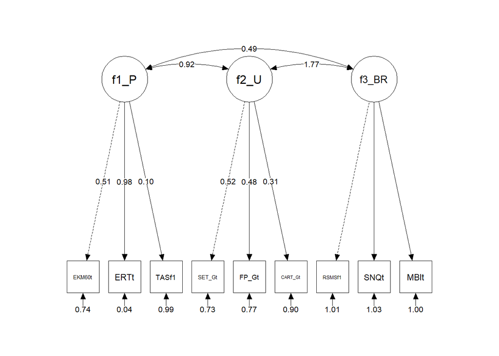

```r
#print(nice_table(stcoefs_fav_CFA_pld), preview = "docx") #Word format output
semPaths(fit_m1_pld,
         whatLabels = "std",  # Display standardized estimates
         layout = "tree2",      # Choose a layout, "tree" is one option
         style = "lisrel",     # Style for the diagram
         nCharNodes = 0,       # Full variable names
         sizeMan = 7,          # Size of manifest variables
         sizeLat = 10,         # Size of latent variables
         edge.label.cex = 0.75, # Adjust the size of the edge labels
         label.cex = 0.8,      # Adjust the size of the node labels
         residuals = TRUE,     # Show residuals
         intercepts = FALSE,   # Hide intercepts
         thresholds = FALSE,
         fade = FALSE,
         edge.color = "black"
         )
```

## SEM EMC data

### Fit indices

```r
results_SEM <- data.frame(round(rbind(fm_sem1, fm_sem2, fm_sem3, fm_sem4, fm_sem5, fm_sem6, fm_sem7, fm_sem8), 3))
modelNames_SEM <- c("3p", "2p: U & BR", "2p: P & BR", "2p: P & U", "1p: P", "1p: U","1p: BR", "0p")
rownames(results_SEM) <- NULL
results_SEM <- cbind(Model = modelNames_SEM, results_SEM)
results_SEM
```

| Model | npar | chisq | df | pvalue | aic | srmr | cfi | ifi | nfi | rmsea | bic |
| --- | --- | --- | --- | --- | --- | --- | --- | --- | --- | --- | --- |
| 3p | 25 | 30.673 | 30 | 0.432 | 1308.220 | 0.084 | 0.988 | 0.990 | 0.696 | 0.022 | 1354.473 |
| 2p: U & BR | 24 | 32.021 | 31 | 0.416 | 1307.567 | 0.083 | 0.982 | 0.985 | 0.682 | 0.026 | 1351.971 |
| 2p: P & BR | 24 | 30.674 | 31 | 0.483 | 1306.221 | 0.084 | 1.000 | 1.005 | 0.696 | 0.000 | 1350.624 |
| 2p: P & U | 24 | 31.052 | 31 | 0.464 | 1306.598 | 0.085 | 0.999 | 0.999 | 0.692 | 0.006 | 1351.002 |
| 1p: P | 23 | 31.053 | 32 | 0.514 | 1304.600 | 0.085 | 1.000 | 1.014 | 0.692 | 0.000 | 1347.153 |
| 1p: U | 23 | 33.028 | 32 | 0.417 | 1306.574 | 0.085 | 0.982 | 0.985 | 0.672 | 0.026 | 1349.127 |
| 1p: BR | 23 | 32.655 | 32 | 0.435 | 1306.201 | 0.087 | 0.988 | 0.990 | 0.676 | 0.021 | 1348.754 |
| 0p | 22 | 38.901 | 33 | 0.221 | 1310.447 | 0.117 | 0.894 | 0.913 | 0.614 | 0.062 | 1351.150 |

```r
results_SEM[,c("Model", "npar", "df", "chisq", "pvalue", "aic", "srmr", "cfi", "ifi")]
```

| Model | npar | df | chisq | pvalue | aic | srmr | cfi | ifi |
| --- | --- | --- | --- | --- | --- | --- | --- | --- |
| 3p | 25 | 30 | 30.673 | 0.432 | 1308.220 | 0.084 | 0.988 | 0.990 |
| 2p: U & BR | 24 | 31 | 32.021 | 0.416 | 1307.567 | 0.083 | 0.982 | 0.985 |
| 2p: P & BR | 24 | 31 | 30.674 | 0.483 | 1306.221 | 0.084 | 1.000 | 1.005 |
| 2p: P & U | 24 | 31 | 31.052 | 0.464 | 1306.598 | 0.085 | 0.999 | 0.999 |
| 1p: P | 23 | 32 | 31.053 | 0.514 | 1304.600 | 0.085 | 1.000 | 1.014 |
| 1p: U | 23 | 32 | 33.028 | 0.417 | 1306.574 | 0.085 | 0.982 | 0.985 |
| 1p: BR | 23 | 32 | 32.655 | 0.435 | 1306.201 | 0.087 | 0.988 | 0.990 |
| 0p | 22 | 33 | 38.901 | 0.221 | 1310.447 | 0.117 | 0.894 | 0.913 |

```r
#print(nice_table(results_SEM[,c("Model", "npar", "df", "chisq", "pvalue", "aic", "srmr", "cfi", "ifi")]), preview = "docx") #Word format output
```

### Model comparisson

```r
anova(fit_sem1, fit_sem2) #not significant
```

|  | Df | AIC | BIC | Chisq | Chisq diff | RMSEA | Df diff | Pr(>Chisq) |
| --- | --- | --- | --- | --- | --- | --- | --- | --- |
| fit_sem1 | 30 | 1308.220 | 1354.473 | 30.67326 | NA | NA | NA | NA |
| fit_sem2 | 31 | 1307.567 | 1351.971 | 32.02080 | 1.347538 | 0.0859908 | 1 | 0.2457091 |

```r
anova(fit_sem1, fit_sem3) #not significant
```

|  | Df | AIC | BIC | Chisq | Chisq diff | RMSEA | Df diff | Pr(>Chisq) |
| --- | --- | --- | --- | --- | --- | --- | --- | --- |
| fit_sem1 | 30 | 1308.220 | 1354.473 | 30.67326 | NA | NA | NA | NA |
| fit_sem3 | 31 | 1306.221 | 1350.624 | 30.67402 | 0.00075944 | 0 | 1 | 0.9780147 |

```r
anova(fit_sem1, fit_sem4) #not significant
```

|  | Df | AIC | BIC | Chisq | Chisq diff | RMSEA | Df diff | Pr(>Chisq) |
| --- | --- | --- | --- | --- | --- | --- | --- | --- |
| fit_sem1 | 30 | 1308.220 | 1354.473 | 30.67326 | NA | NA | NA | NA |
| fit_sem4 | 31 | 1306.598 | 1351.002 | 31.05166 | 0.378394 | 0 | 1 | 0.538464 |

```r
#So: models 2-4 are not fitting sign than model 1

anova(fit_sem1, fit_sem5) #not significant
```

|  | Df | AIC | BIC | Chisq | Chisq diff | RMSEA | Df diff | Pr(>Chisq) |
| --- | --- | --- | --- | --- | --- | --- | --- | --- |
| fit_sem1 | 30 | 1308.22 | 1354.473 | 30.67326 | NA | NA | NA | NA |
| fit_sem5 | 32 | 1304.60 | 1347.153 | 31.05304 | 0.3797736 | 0 | 2 | 0.8270527 |

```r
anova(fit_sem1, fit_sem6) #not significant
```

|  | Df | AIC | BIC | Chisq | Chisq diff | RMSEA | Df diff | Pr(>Chisq) |
| --- | --- | --- | --- | --- | --- | --- | --- | --- |
| fit_sem1 | 30 | 1308.220 | 1354.473 | 30.67326 | NA | NA | NA | NA |
| fit_sem6 | 32 | 1306.574 | 1349.127 | 33.02761 | 2.354344 | 0.06139721 | 2 | 0.308149 |

```r
anova(fit_sem1, fit_sem7) #not significant
```

|  | Df | AIC | BIC | Chisq | Chisq diff | RMSEA | Df diff | Pr(>Chisq) |
| --- | --- | --- | --- | --- | --- | --- | --- | --- |
| fit_sem1 | 30 | 1308.220 | 1354.473 | 30.67326 | NA | NA | NA | NA |
| fit_sem7 | 32 | 1306.201 | 1348.754 | 32.65457 | 1.981303 | 0 | 2 | 0.3713347 |

```r
#So: models 5-7 are not fitting sign than model 1

anova(fit_sem2, fit_sem6) #not significant
```

|  | Df | AIC | BIC | Chisq | Chisq diff | RMSEA | Df diff | Pr(>Chisq) |
| --- | --- | --- | --- | --- | --- | --- | --- | --- |
| fit_sem2 | 31 | 1307.567 | 1351.971 | 32.02080 | NA | NA | NA | NA |
| fit_sem6 | 32 | 1306.574 | 1349.127 | 33.02761 | 1.006806 | 0.01203398 | 1 | 0.3156691 |

```r
anova(fit_sem2, fit_sem7) #not significant
```

|  | Df | AIC | BIC | Chisq | Chisq diff | RMSEA | Df diff | Pr(>Chisq) |
| --- | --- | --- | --- | --- | --- | --- | --- | --- |
| fit_sem2 | 31 | 1307.567 | 1351.971 | 32.02080 | NA | NA | NA | NA |
| fit_sem7 | 32 | 1306.201 | 1348.754 | 32.65457 | 0.6337652 | 0 | 1 | 0.4259776 |

```r
#So: models 6-7 are not fitting sign than model 2

anova(fit_sem3, fit_sem5) #not significant
```

|  | Df | AIC | BIC | Chisq | Chisq diff | RMSEA | Df diff | Pr(>Chisq) |
| --- | --- | --- | --- | --- | --- | --- | --- | --- |
| fit_sem3 | 31 | 1306.221 | 1350.624 | 30.67402 | NA | NA | NA | NA |
| fit_sem5 | 32 | 1304.600 | 1347.153 | 31.05304 | 0.3790142 | 0 | 1 | 0.5381313 |

```r
anova(fit_sem3, fit_sem7) #not significant
```

|  | Df | AIC | BIC | Chisq | Chisq diff | RMSEA | Df diff | Pr(>Chisq) |
| --- | --- | --- | --- | --- | --- | --- | --- | --- |
| fit_sem3 | 31 | 1306.221 | 1350.624 | 30.67402 | NA | NA | NA | NA |
| fit_sem7 | 32 | 1306.201 | 1348.754 | 32.65457 | 1.980543 | 0.144439 | 1 | 0.1593332 |

```r
#So: models 5 & 7 are not fitting sign than model 3

anova(fit_sem4, fit_sem5) #not significant
```

|  | Df | AIC | BIC | Chisq | Chisq diff | RMSEA | Df diff | Pr(>Chisq) |
| --- | --- | --- | --- | --- | --- | --- | --- | --- |
| fit_sem4 | 31 | 1306.598 | 1351.002 | 31.05166 | NA | NA | NA | NA |
| fit_sem5 | 32 | 1304.600 | 1347.153 | 31.05304 | 0.001379652 | 0 | 1 | 0.9703705 |

```r
anova(fit_sem4, fit_sem6) #not significant
```

|  | Df | AIC | BIC | Chisq | Chisq diff | RMSEA | Df diff | Pr(>Chisq) |
| --- | --- | --- | --- | --- | --- | --- | --- | --- |
| fit_sem4 | 31 | 1306.598 | 1351.002 | 31.05166 | NA | NA | NA | NA |
| fit_sem6 | 32 | 1306.574 | 1349.127 | 33.02761 | 1.97595 | 0.1441003 | 1 | 0.1598177 |

```r
#So: models 5-6 are not fitting sign than model 4

anova(fit_sem5, fit_sem8) #significant
```

|  | Df | AIC | BIC | Chisq | Chisq diff | RMSEA | Df diff | Pr(>Chisq) |
| --- | --- | --- | --- | --- | --- | --- | --- | --- |
| fit_sem5 | 32 | 1304.600 | 1347.153 | 31.05304 | NA | NA | NA | NA |
| fit_sem8 | 33 | 1310.447 | 1351.150 | 38.90065 | 7.847612 | 0.3816987 | 1 | 0.005088788 |

```r
anova(fit_sem6, fit_sem8) #significant
```

|  | Df | AIC | BIC | Chisq | Chisq diff | RMSEA | Df diff | Pr(>Chisq) |
| --- | --- | --- | --- | --- | --- | --- | --- | --- |
| fit_sem6 | 32 | 1306.574 | 1349.127 | 33.02761 | NA | NA | NA | NA |
| fit_sem8 | 33 | 1310.447 | 1351.150 | 38.90065 | 5.873042 | 0.3219965 | 1 | 0.01537447 |

```r
anova(fit_sem7, fit_sem8) #significant
```

|  | Df | AIC | BIC | Chisq | Chisq diff | RMSEA | Df diff | Pr(>Chisq) |
| --- | --- | --- | --- | --- | --- | --- | --- | --- |
| fit_sem7 | 32 | 1306.201 | 1348.754 | 32.65457 | NA | NA | NA | NA |
| fit_sem8 | 33 | 1310.447 | 1351.150 | 38.90065 | 6.246083 | 0.334094 | 1 | 0.01244683 |

```r
#So, model 8 fits significantly worse than models 5-7

#Out of models 5-7, model 5 is in favour based on the fit indices
```

### Favoured model

```r
stcoefs_fav_SEM <- standardizedSolution(fit_sem5)
nice_table(stcoefs_fav_SEM)
```

| lhs | op | rhs | est.std | se | z | p | ci.lower | ci.upper |
| --- | --- | --- | --- | --- | --- | --- | --- | --- |
| f1_P | =~ | EKM60t | 0.91 | 0.09 | 10.11 | < .001*** | 0.74 | 1.09 |
| f1_P | =~ | ERTt | 0.68 | 0.10 | 6.52 | < .001*** | 0.47 | 0.88 |
| f1_P | =~ | TASf1 | 0.27 | 0.15 | 1.80 | .071 | -0.02 | 0.55 |
| f2_U | =~ | SET_Gt | 0.25 | 0.16 | 1.51 | .131 | -0.07 | 0.56 |
| f2_U | =~ | FP_Gt | 0.64 | 0.13 | 5.07 | < .001*** | 0.39 | 0.88 |
| f2_U | =~ | CART_Gt | 0.67 | 0.12 | 5.42 | < .001*** | 0.43 | 0.92 |
| f3_BR | =~ | RSMSf1 |  |  |  |  |  |  |
| f3_BR | =~ | SNQt |  |  |  |  |  |  |
| f3_BR | =~ | MBIt |  |  |  |  |  |  |
| TQt | ~ | f1_P | 0.42 | 0.13 | 3.17 | .002** | 0.16 | 0.68 |
| TQt | ~ | f2_U | 0.00 | 0.00 |  |  | 0.00 | 0.00 |
| TQt | ~ | f3_BR |  |  |  |  |  |  |
| f1_P | ~~ | f2_U | 0.72 | 0.15 | 4.85 | < .001*** | 0.43 | 1.01 |
| f1_P | ~~ | f3_BR | 0.53 | 0.45 | 1.17 | .242 | -0.35 | 1.41 |
| f2_U | ~~ | f3_BR | 0.77 | 0.62 | 1.24 | .214 | -0.44 | 1.98 |
| EKM60t | ~~ | EKM60t | 0.16 | 0.17 | 0.99 | .321 | -0.16 | 0.49 |
| ERTt | ~~ | ERTt | 0.54 | 0.14 | 3.86 | < .001*** | 0.27 | 0.82 |
| TASf1 | ~~ | TASf1 | 0.93 | 0.08 | 11.93 | < .001*** | 0.78 | 1.08 |
| SET_Gt | ~~ | SET_Gt | 0.94 | 0.08 | 11.81 | < .001*** | 0.78 | 1.10 |
| FP_Gt | ~~ | FP_Gt | 0.59 | 0.16 | 3.71 | < .001*** | 0.28 | 0.91 |
| CART_Gt | ~~ | CART_Gt | 0.55 | 0.17 | 3.27 | .001** | 0.22 | 0.87 |
| RSMSf1 | ~~ | RSMSf1 | 1.33 | 0.52 | 2.55 | .011* | 0.31 | 2.35 |
| SNQt | ~~ | SNQt | 1.04 | 0.06 | 18.71 | < .001*** | 0.93 | 1.15 |
| MBIt | ~~ | MBIt | 1.02 | 0.04 | 26.18 | < .001*** | 0.95 | 1.10 |
| TQt | ~~ | TQt | 0.82 | 0.11 | 7.32 | < .001*** | 0.60 | 1.04 |
| f1_P | ~~ | f1_P | 1.00 | 0.00 |  |  | 1.00 | 1.00 |
| f2_U | ~~ | f2_U | 1.00 | 0.00 |  |  | 1.00 | 1.00 |
| f3_BR | ~~ | f3_BR |  |  |  |  |  |  |

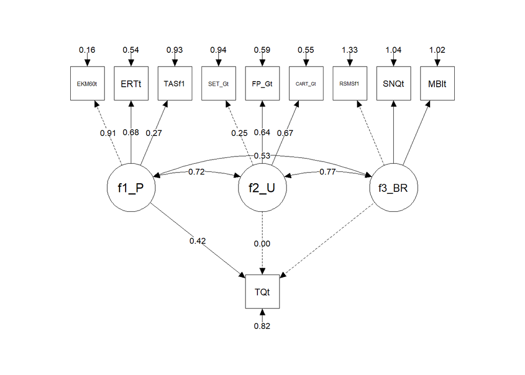

```r
#print(nice_table(stcoefs_fav_SEM), preview = "docx") #Word format output
semPaths(fit_sem5,
         whatLabels = "std",  # Display standardized estimates
         layout = "tree2",      # Choose a layout, "tree" is one option
         style = "lisrel",     # Style for the diagram
         nCharNodes = 0,       # Full variable names
         sizeMan = 7,          # Size of manifest variables
         sizeLat = 10,         # Size of latent variables
         edge.label.cex = 0.75, # Adjust the size of the edge labels
         label.cex = 0.8,      # Adjust the size of the node labels
         residuals = TRUE,     # Show residuals
         intercepts = FALSE,   # Hide intercepts
         thresholds = FALSE,
         fade = FALSE,
         edge.color = "black"
         )
```